# Predicting Who Would Subscribe for a Term Deposit in a Bank

## Phase 2: Predictive Modelling

#### Prepared By: Sharanpreet Singh

- Introduction
  - Phase 1 Summary
  - Report Overview
  - Overview of Methodology
- Data Preparation
  - Dataset Retrieval
  - Encoding Categorical Features
  - Scaling Features
- Predictive Modelling
  - Feature Selection
  - Model Fitting and Tuning
  - Model Comparison
- Critique and Limitations
- Summary and Conclusions
- I. Project Summary
- II. Summary of Findings
- III. Conclusions
- References

## Introduction

### Phase 1 Summary

This project (as the title states) intends to predict who would subscribe for a term deposit by using the various descriptive features at-hand. The data-set used for the purpose of the entire project has been sourced from the UCI Machine Learning Repository (Bank Marketing Data Set, 2014). The information contained in the dataset is about the clients of a Portuguese Bank, dated from May 2008 to November 2010.

In Phase 1: Data Preparation & Visualization, we defined our descriptive features, and the target feature `term_deposit`. This phase was related to the Data Preprocessing of the data-set. The data-set did contain certain missing values denoted as `unknown` in features such as `education, housing, loan, marital, default, job` which were removed citing that their contribution was almost negligible. The data-set happened to contain 10 duplicate observations which were also removed as they would serve no value for the purposes of Predictive Modelling. Furthermore, a descriptive feature titled `duration` implying the duration of the call that the customer representative of the bank had with the client was not considered as part of the final data-frame as the whole purpose of Predictive Modelling is to provide knowledge as to who would be worth contacting, and hence preventing expenditure. Finally, we went on to rename certain columns appropriately, and we also renamed the target feature which was denoted as `y` to `term_deposit`.

The second part of the Phase-1 report was to perform Exploratory Data Analysis and Visualization using the pre-processed data-set. We performed Univariate, Bi-variate analysis along with three-variable plots. We found that the problem at-hand is a highly imbalanced one, and that would make sense as it is a marketing campaign. Other observations included that most of the clients were employed as `admins`, and that most of the clients held a university degree. The majority of the clients ranged between the age of 30 and 40, and almost 85% of the clients were being contacted for the first-time. Our data-set included some social and economic features as well, and they had a role to play in the outcome of the target variable, for instance, the `cons_price_idx` shared a reverse relationship with `term_deposit`, and as the `emp_var_rate` decreased, more people subscribed for a term deposit at the bank. A point that was evident that as the `euribor3m` reduced over-time, so did the `cons_conf_idx`, and hence reduced the `term_deposit` subscription.

The work done in Phase-1 was the foundation stone for the tasks that are to be done in this report (Phase-2). Before starting to predict anything, we need to be aware of what we are dealing with. Doing the Data Wrangling Process helps to remove all the unnecessary data from the data-set which would have during the modelling section only increased computational time and a possibly false prediction model to be deployed. Not to mention that during the feature-selection process `duration` would have easily come up in the top-10 features because having `duration` adds no-value to the task of predictive modelling, as we intend to find-out who are the clients that are worth contacting by the bank. Furthermore, duplicate observations in the data-set as stated earlier would not provide any benefit for predictive modelling. Hence, the tasks performed in Phase-1 were of paramount importance to what is supposed to be done in this report.

**Note**: From the data preparation stage, tasks such as One-Hot-Encoding (or Integer-Encoding), Scaling and Sampling will be performed in this report.

### Report Overview

The main aim of this project is to predict who will subscribe for a term deposit at the bank in question, and we will be doing so by fitting and comparing different classifiers. So far our data-set contains 10 nominal categorical features (`day_of_week`, `month`, `default`, `housing`,`loan`, `job`, `marital_status`, `education`, `contact`, and `poutcome`), and 9 numeric features (`p_days`, `age`, `campaign`, `previous`, `emp_var_rate`, `cons_price_idx`, `cons_conf_idx`, `euribor3m`, and `nr_employed`). Our target feature `term_deposit` has two classes namely "yes" and "no".

This phase would proceed with converting the categorical features to numeric which would internally involve encoding of nominal descriptive features. For the nominal categorical features, we will follow the One-Hot-Encoding process. After having encoded all the descriptive features, we will encode the target feature, considering the "yes" outcome to be the positive class. One of the most crucial parts before modelling is that of "Scaling" the features. Scaling or Normalization becomes important as the observations in the descriptive features might take different range of values, and hence impacting the predicting power of the model. We will be performing the "Min-Max Scaling".

Concluding to the completion of the above tasks, we then proceed towards core predictive modelling techniques specifically "Feature Selection" for a start. This is an important step as in the real-world scenario using all the descriptive features to predict a particular outcome would increase the computational time of the task and prone our models to overfitting, and hence we will identify the top-10 features using the Random Forest Importance and the F-Score method. After which, we will be sampling our data to 5000 observations considering the processing limitations of this machine. We then split our data into test and train following a 70:30 split ratio. Furthermore, we move on to "Model Fitting and Tuning" through which we will be finding the ideal hyperparameters for each algorithm that we will be using along with a particular set of features. The scoring metric for each algorithm would be `roc_auc` as this is a binary classification problem, moreover, a highly imbalanced on as well. As an additional task, we will also be fitting a neural network algorithm into our sampled data-set including the fine-tuning of 5 different Neural Network Hyperparameters. The final step of the predictive modelling includes "Model Comparison", we will be calculating the AUC Scores via the `cross_val_score` method using paired t-tests, and find out the best performing algorithm, along with other criteria such as `confusion matrices` and `classification reports`.

The next section "Critique and Limitations" would include the limitations of the approach we have followed, at the same-time providing possible solutions to drawbacks. "Summary and Conclusions" would include the summary of the entire project report i.e. Phase 1 and Phase 2, followed by our findings from having performed on this data-set. And in the "Conclusions" section, we will reflect back to our goals and objectives with the end-result of this report.

**Note**: Before beginning to work with any sklearn modules, we will convert our pandas data-frame to a numpy array.

### Overview of Methodology

Our journey to effectively selecting the correct model of our problem, would begin with the encoding of the categorical features, and since this is a classification problem, our target feature `term_deposit` is also a categorical feature. We would encode our target feature after splitting our main data-set into one for descriptive features, and the other for the target feature. Following which, all the descriptive features with only 2 levels, would be encoded with only one binary variable using the `pandas` function of `get_dummies()`, and normally for other categorical features. We will then 'Scale' our data, as to normalise it. The scaling would be done only on the descriptive features data-set. Before the scaling is performed, we will save our original data-set to preserve the column names, as the output of the `MinMaxScaler` function is a `numpy` array. We will then proceed towards core predictive modelling, beginning with Feature Selection.

In Feature Selection, we would ideally be trying to find out the best 10 features using the Random Forest Importance method and the F-Score method, we won't be using these 10 feature through out the modelling stage, since we intend to tune the hyperparameters of a specific algorithm using different set of features. We then proceed towards the Model Fitting and Tuning stage, where-in, we will work with four different algorithms, namely, K-Nearest Neighbors, Decision Tree, Naive Bayes, and Logistic Regressor and tune their hyperparameters via their respective classifier, and by using the custom sourced class *RFISelector()* as part of the pipeline. We will be performing a GridSearch approach using a 5 Fold Cross Validation technique without any repetitions using `roc_auc` as the scoring metric. After which, we will also have a look at how each algorithm performs on the test data.

The final stage of the predictive modelling process would be the Model Comparison. In it, we will be comparing the performance of our models using thier cross validation scores on the test data. We will draw conclusions by conducting a paired *t-test* (by keeping the same random state through-out for each model), to know if the difference between the performance of the various combination of models is statistically significant or not.

We will also reflect back to our problem at-hand, and make the final call as to which model is to be picked for deployment based on the `classification report` and the `confusion matrix`.

## Data Preparation

### Dataset Retrieval

We will begin with loading the "prepared" data-set from phase-1. After the phase-1 completion, we had 30,476 observations with 20 features (including the target feature). The raw data-set, however, was retrieved from the UCI Machine Learning Repository (Bank Marketing Data Set, 2014).

```python
#Loading the various packages and modules that will be needed for this report

import warnings
warnings.filterwarnings("ignore")

import numpy as np
import pandas as pd
import matplotlib.pyplot as plt
import seaborn as sns
from sklearn import metrics

pd.set_option('display.max_columns', None) #Displays all columns in the dataset while printing

%matplotlib inline
%config InlineBackend.figure_format ='retina'
plt.style.use('seaborn')
```

```python
#Reading the preprocessed data-set

clients = pd.read_csv("Part2_TermDeposit.csv", encoding = 'utf8')
```

Since the file has been read into memory, we can display observations from it (as shown below).

```python
# Check to see if the dataset has been imported, displaying a random sample.
# The random_state argument assures that the output remains same irrespective of the times the code is run.

clients.sample(10,random_state=999).round(3)
```

|  | age | job | marital_status | education | default | housing | loan | contact | month | day_of_week | campaign | pdays | previous | poutcome | emp_var_rate | cons_price_idx | cons_conf_idx | euribor3m | nr_employed | term_deposit |
| --- | --- | --- | --- | --- | --- | --- | --- | --- | --- | --- | --- | --- | --- | --- | --- | --- | --- | --- | --- | --- |
| 25258 | 41 | blue-collar | married | high.school | no | yes | no | cellular | may | fri | 3 | 999 | 0 | nonexistent | -1.8 | 92.893 | -46.2 | 1.250 | 5099.1 | no |
| 27051 | 36 | admin. | divorced | university.degree | no | no | no | cellular | aug | mon | 1 | 5 | 1 | success | -2.9 | 92.201 | -31.4 | 0.884 | 5076.2 | yes |
| 8901 | 33 | admin. | single | high.school | no | yes | no | cellular | jul | thu | 14 | 999 | 0 | nonexistent | 1.4 | 93.918 | -42.7 | 4.963 | 5228.1 | no |
| 8396 | 25 | blue-collar | married | basic.9y | no | yes | no | cellular | jul | wed | 3 | 999 | 0 | nonexistent | 1.4 | 93.918 | -42.7 | 4.962 | 5228.1 | no |
| 21607 | 31 | blue-collar | married | basic.6y | no | yes | no | cellular | may | mon | 7 | 999 | 0 | nonexistent | -1.8 | 92.893 | -46.2 | 1.354 | 5099.1 | no |
| 651 | 31 | technician | married | professional.course | no | yes | no | telephone | may | wed | 6 | 999 | 0 | nonexistent | 1.1 | 93.994 | -36.4 | 4.856 | 5191.0 | no |
| 13129 | 38 | technician | single | professional.course | no | yes | no | cellular | aug | fri | 1 | 999 | 0 | nonexistent | 1.4 | 93.444 | -36.1 | 4.966 | 5228.1 | no |
| 3569 | 28 | blue-collar | single | basic.9y | no | yes | no | telephone | may | mon | 1 | 999 | 0 | nonexistent | 1.1 | 93.994 | -36.4 | 4.857 | 5191.0 | no |
| 23052 | 36 | blue-collar | married | basic.9y | no | yes | no | cellular | may | fri | 2 | 999 | 0 | nonexistent | -1.8 | 92.893 | -46.2 | 1.313 | 5099.1 | no |
| 16393 | 45 | admin. | married | high.school | no | yes | no | cellular | nov | mon | 1 | 999 | 0 | nonexistent | -0.1 | 93.200 | -42.0 | 4.191 | 5195.8 | no |

We can see that the data-set has been loaded into memory, and we can begin with our tasks concerning this phase of the project.

### Encoding Categorical Features

Since our data-set happens to contain categorical descriptive features, we have to encode them to numeric before we proceed with the predictive-modelling section. Also, since this is a classification problem, we have to encode the target feature as numeric as well.

### Encoding the Target Feature

Before encoding the target feature `term_deposit`, we will split the target feature into a different data-frame 'target', and the descriptive features to 'data'. We already know that this is a highly imbalanced problem but nevertheless, we will check the proportions of the result as well.

```python
# Splitting the clients data-frame into target and data

target = clients['term_deposit']
data = clients.drop(columns=['term_deposit'])

# Getting the value proportions of the target feature

target.value_counts()
```

```
no     26618
yes     3858
Name: term_deposit, dtype: int64
```

The above lines of code have been executed successfully, and we can move on towards Label Encoding the classes of the target feature.

```python
# Label Encoding the positive class "yes" as 1 and "no" as o
target = target.replace({"yes":1, "no":0})
target.value_counts()
```

```
0    26618
1     3858
Name: term_deposit, dtype: int64
```

As evident from the above lines of code, we have labelled the positive class (with respect to this project) "yes" as 1, and "no" as 0. We have viewed the value proportions again as a precautionary check to confirm if the encoding was done correctly. The proportions help us to know that the data-set, we have in-hand is a highly imbalanced one, and during the splitting stage of the data-set into training and test data-set, we will `stratify` it.

### Encoding the Descriptive Features

Before encoding the descriptive features, we will check which data-type is allotted to each feature, and if there is any mismatch, we will perform the type-conversion as deemed necessary.

```python
# Checking the data-type of each descriptive feature
data.dtypes
```

```
age                 int64
job                object
marital_status     object
education          object
default            object
housing            object
loan               object
contact            object
month              object
day_of_week        object
campaign            int64
pdays               int64
previous            int64
poutcome           object
emp_var_rate      float64
cons_price_idx    float64
cons_conf_idx     float64
euribor3m         float64
nr_employed       float64
dtype: object
```

The allotted data-types to each descriptive feature are correct as all the categorical features have `object` as their data-type, and therefore, we can move towards encoding the categorical features.

All the categorical features are **Nominal** as there is no actual ordering in any of the features domain values. Due to which, we do not need to perform separate encoding for both nominal and ordinal, and we can proceed with only One-Hot-Encoding for the features.

```python
# Combining categorical features into a list

categorical_features = data.columns[data.dtypes==np.object].tolist()
categorical_features
```

```
['job',
 'marital_status',
 'education',
 'default',
 'housing',
 'loan',
 'contact',
 'month',
 'day_of_week',
 'poutcome']
```

```python
# Obtaining the list of levels in the categorical features

for feature in categorical_features:
    print("Levels for " + feature + ":")
    print(data[feature].value_counts())
    print('\n')
```

```
Levels for job:
admin.           8734
blue-collar      5674
technician       5469
services         2856
management       2311
retired          1215
self-employed    1092
entrepreneur     1089
unemployed        738
housemaid         690
student           608
Name: job, dtype: int64


Levels for marital_status:
married     17487
single       9437
divorced     3552
Name: marital_status, dtype: int64


Levels for education:
university.degree      10408
high.school             7697
professional.course     4318
basic.9y                4274
basic.4y                2380
basic.6y                1388
illiterate                11
Name: education, dtype: int64


Levels for default:
no     30473
yes        3
Name: default, dtype: int64


Levels for housing:
```

[output cut: 30 more lines]

```

Levels for day_of_week:
thu    6391
mon    6278
wed    6125
tue    5951
fri    5731
Name: day_of_week, dtype: int64


Levels for poutcome:
nonexistent    25826
failure         3460
success         1190
Name: poutcome, dtype: int64
```

From the above list of levels, we can infer that `default`, `housing`, `loan`, and `contact` each have only 2 levels, hence, for each of them, we will be defining only one binary variable using the `get_dummies()` method.

```python
# Performing OHE for features with only 2 levels

for feature in categorical_features:
    if(data[feature].nunique()==2):
        data[feature] = pd.get_dummies(data[feature], drop_first=True) #To encode only a single binary variable

# Performing OHE for features with more than 2 levels
data = pd.get_dummies(data)
```

We have successfully performed One-Hot-Encoding on all the categorical features, and to confirm let us have a look at the sample of the modified data-frame `data`.

```python
# Confirmatory check for OHE
data.sample(6, random_state=999)
```

|  | age | default | housing | loan | contact | campaign | pdays | previous | emp_var_rate | cons_price_idx | cons_conf_idx | euribor3m | nr_employed | job_admin. | job_blue-collar | job_entrepreneur | job_housemaid | job_management | job_retired | job_self-employed | job_services | job_student | job_technician | job_unemployed | marital_status_divorced | marital_status_married | marital_status_single | education_basic.4y | education_basic.6y | … |
| --- | --- | --- | --- | --- | --- | --- | --- | --- | --- | --- | --- | --- | --- | --- | --- | --- | --- | --- | --- | --- | --- | --- | --- | --- | --- | --- | --- | --- | --- | --- |
| 25258 | 41 | 0 | 1 | 0 | 0 | 3 | 999 | 0 | -1.8 | 92.893 | -46.2 | 1.250 | 5099.1 | 0 | 1 | 0 | 0 | 0 | 0 | 0 | 0 | 0 | 0 | 0 | 0 | 1 | 0 | 0 | 0 | … |
| 27051 | 36 | 0 | 0 | 0 | 0 | 1 | 5 | 1 | -2.9 | 92.201 | -31.4 | 0.884 | 5076.2 | 1 | 0 | 0 | 0 | 0 | 0 | 0 | 0 | 0 | 0 | 0 | 1 | 0 | 0 | 0 | 0 | … |
| 8901 | 33 | 0 | 1 | 0 | 0 | 14 | 999 | 0 | 1.4 | 93.918 | -42.7 | 4.963 | 5228.1 | 1 | 0 | 0 | 0 | 0 | 0 | 0 | 0 | 0 | 0 | 0 | 0 | 0 | 1 | 0 | 0 | … |
| 8396 | 25 | 0 | 1 | 0 | 0 | 3 | 999 | 0 | 1.4 | 93.918 | -42.7 | 4.962 | 5228.1 | 0 | 1 | 0 | 0 | 0 | 0 | 0 | 0 | 0 | 0 | 0 | 0 | 1 | 0 | 0 | 0 | … |
| 21607 | 31 | 0 | 1 | 0 | 0 | 7 | 999 | 0 | -1.8 | 92.893 | -46.2 | 1.354 | 5099.1 | 0 | 1 | 0 | 0 | 0 | 0 | 0 | 0 | 0 | 0 | 0 | 0 | 1 | 0 | 0 | 1 | … |
| 651 | 31 | 0 | 1 | 0 | 1 | 6 | 999 | 0 | 1.1 | 93.994 | -36.4 | 4.856 | 5191.0 | 0 | 0 | 0 | 0 | 0 | 0 | 0 | 0 | 0 | 1 | 0 | 0 | 1 | 0 | 0 | 0 | … |

The data-frame looks good, and we can move towards the "**Scaling**" of the descriptive features.

```python
# Checking the final shape of the data-frame
data.shape
```

```
(30476, 52)
```

After performing One-Hot-Encoding, we now have a total of 52 columns, deciding which and how many to be used will done in the **Hyperparameter Tuning** stage.

### Scaling Features

An important step before moving towards the modelling section is that of "Normalizing" the data-set. It is crucial as some observations may contain different variance as compared to others in the data-set, and hence, the predicting power or the actual prediction may come out to be **False**. For the purpose of this project, we will be using the **Min-Max Scaling method**.

**Note**: Since this scaling method uses a *fit_transform* whose output is a `numpy` array due to which the column names will be lost, hence we will keep a copy of our original data-frame before-hand.

```python
# Storing a copy of the data-frame
data_copy = data.copy()
```

```python
# Implementing the Min-Max Scaling Method

from sklearn import preprocessing

data_scaled = preprocessing.MinMaxScaler()
data_scaled.fit(data)
data = data_scaled.fit_transform(data)
```

```python
# Confirming the output of the above scaling
pd.DataFrame(data,columns= data_copy.columns).sample(10, random_state=999)
```

|  | age | default | housing | loan | contact | campaign | pdays | previous | emp_var_rate | cons_price_idx | cons_conf_idx | euribor3m | nr_employed | job_admin. | job_blue-collar | job_entrepreneur | job_housemaid | job_management | job_retired | job_self-employed | job_services | job_student | job_technician | job_unemployed | marital_status_divorced | marital_status_married | marital_status_single | education_basic.4y | education_basic.6y | … |
| --- | --- | --- | --- | --- | --- | --- | --- | --- | --- | --- | --- | --- | --- | --- | --- | --- | --- | --- | --- | --- | --- | --- | --- | --- | --- | --- | --- | --- | --- | --- |
| 25258 | 0.298701 | 0.0 | 1.0 | 0.0 | 0.0 | 0.047619 | 1.000000 | 0.000000 | 0.333333 | 0.269680 | 0.192469 | 0.139651 | 0.512287 | 0.0 | 1.0 | 0.0 | 0.0 | 0.0 | 0.0 | 0.0 | 0.0 | 0.0 | 0.0 | 0.0 | 0.0 | 1.0 | 0.0 | 0.0 | 0.0 | … |
| 27051 | 0.233766 | 0.0 | 0.0 | 0.0 | 0.0 | 0.000000 | 0.005005 | 0.142857 | 0.104167 | 0.000000 | 0.811715 | 0.056676 | 0.425709 | 1.0 | 0.0 | 0.0 | 0.0 | 0.0 | 0.0 | 0.0 | 0.0 | 0.0 | 0.0 | 0.0 | 1.0 | 0.0 | 0.0 | 0.0 | 0.0 | … |
| 8901 | 0.194805 | 0.0 | 1.0 | 0.0 | 0.0 | 0.309524 | 1.000000 | 0.000000 | 1.000000 | 0.669135 | 0.338912 | 0.981410 | 1.000000 | 1.0 | 0.0 | 0.0 | 0.0 | 0.0 | 0.0 | 0.0 | 0.0 | 0.0 | 0.0 | 0.0 | 0.0 | 0.0 | 1.0 | 0.0 | 0.0 | … |
| 8396 | 0.090909 | 0.0 | 1.0 | 0.0 | 0.0 | 0.047619 | 1.000000 | 0.000000 | 1.000000 | 0.669135 | 0.338912 | 0.981183 | 1.000000 | 0.0 | 1.0 | 0.0 | 0.0 | 0.0 | 0.0 | 0.0 | 0.0 | 0.0 | 0.0 | 0.0 | 0.0 | 1.0 | 0.0 | 0.0 | 0.0 | … |
| 21607 | 0.168831 | 0.0 | 1.0 | 0.0 | 0.0 | 0.142857 | 1.000000 | 0.000000 | 0.333333 | 0.269680 | 0.192469 | 0.163228 | 0.512287 | 0.0 | 1.0 | 0.0 | 0.0 | 0.0 | 0.0 | 0.0 | 0.0 | 0.0 | 0.0 | 0.0 | 0.0 | 1.0 | 0.0 | 0.0 | 1.0 | … |
| 651 | 0.168831 | 0.0 | 1.0 | 0.0 | 1.0 | 0.119048 | 1.000000 | 0.000000 | 0.937500 | 0.698753 | 0.602510 | 0.957153 | 0.859735 | 0.0 | 0.0 | 0.0 | 0.0 | 0.0 | 0.0 | 0.0 | 0.0 | 0.0 | 1.0 | 0.0 | 0.0 | 1.0 | 0.0 | 0.0 | 0.0 | … |
| 13129 | 0.259740 | 0.0 | 1.0 | 0.0 | 0.0 | 0.000000 | 1.000000 | 0.000000 | 1.000000 | 0.484412 | 0.615063 | 0.982090 | 1.000000 | 0.0 | 0.0 | 0.0 | 0.0 | 0.0 | 0.0 | 0.0 | 0.0 | 0.0 | 1.0 | 0.0 | 0.0 | 0.0 | 1.0 | 0.0 | 0.0 | … |
| 3569 | 0.129870 | 0.0 | 1.0 | 0.0 | 1.0 | 0.000000 | 1.000000 | 0.000000 | 0.937500 | 0.698753 | 0.602510 | 0.957379 | 0.859735 | 0.0 | 1.0 | 0.0 | 0.0 | 0.0 | 0.0 | 0.0 | 0.0 | 0.0 | 0.0 | 0.0 | 0.0 | 0.0 | 1.0 | 0.0 | 0.0 | … |
| 23052 | 0.233766 | 0.0 | 1.0 | 0.0 | 0.0 | 0.023810 | 1.000000 | 0.000000 | 0.333333 | 0.269680 | 0.192469 | 0.153933 | 0.512287 | 0.0 | 1.0 | 0.0 | 0.0 | 0.0 | 0.0 | 0.0 | 0.0 | 0.0 | 0.0 | 0.0 | 0.0 | 1.0 | 0.0 | 0.0 | 0.0 | … |
| 16393 | 0.350649 | 0.0 | 1.0 | 0.0 | 0.0 | 0.000000 | 1.000000 | 0.000000 | 0.687500 | 0.389322 | 0.368201 | 0.806393 | 0.877883 | 1.0 | 0.0 | 0.0 | 0.0 | 0.0 | 0.0 | 0.0 | 0.0 | 0.0 | 0.0 | 0.0 | 0.0 | 1.0 | 0.0 | 0.0 | 0.0 | … |

We can see that all of the descriptive features (except the binary level features) have been scaled between the range of 0 and 1. This confirms the completion of our Data Preparation stage, and we can proceed towards Feature Selection.

## Predictive Modelling

### Feature Selection

One of the most important steps in the concepts of Machine Learning. We will work with the top 10 features only as with the complete set of features, we might run into the problem of overfitting. Having stated that, in the **Model Fitting and Tuning** stage, we will work with different hyper-parameter for each algorithm against specific number of features.

We would be performing the Feature Selection and Ranking using:

```
1. Random Forest Importance (Filter Method)
2. F-Score (Filter Method)
```

Before we proceed, we will convert our target feature `term_deposit` into a numpy array as well for working with `sklearn` modules.

```python
# Converting our target feature to a numpy array as well
target = target.values
```

#### I. Random Forest Importance

For the first, feature-selection and ranking, we will work with the Random Forest Importance which is essentially a filter-based method.

```python
# Implementing the Random Forest Classifier

from sklearn.ensemble import RandomForestClassifier

number_features=10
model_rfi = RandomForestClassifier(n_estimators = 100) # Using 100 Trees
model_rfi.fit(data,target)
fs_indices_rfi = np.argsort(model_rfi.feature_importances_)[::-1][0:number_features] # Selecting the top 10

top_features_rfi= data_copy.columns[fs_indices_rfi].values
top_features_rfi
```

```
array(['age', 'euribor3m', 'campaign', 'nr_employed', 'housing', 'pdays',
       'cons_conf_idx', 'emp_var_rate', 'loan', 'poutcome_success'],
      dtype=object)
```

```python
# Obtaining the importances of each features

feature_importance_rfi = model_rfi.feature_importances_[fs_indices_rfi]
feature_importance_rfi
```

```
array([0.17265549, 0.12458718, 0.08685428, 0.04495426, 0.04086785,
       0.04081801, 0.03152681, 0.02685408, 0.02533494, 0.02454287])
```

Plotting the best features for better representation.

**Note**: The following function has been sourced from the SK Part 2 tutorial (Feature Ranking, 2022).

```python
plt.style.use('seaborn')
def importances_plot(best_features, scores, method_name):
    sns.barplot(scores, best_features, palette='viridis')
    plt.title(method_name + ' Feature Importances')
    plt.xlabel("Importance")
    plt.ylabel("Features")
    plt.show()
```

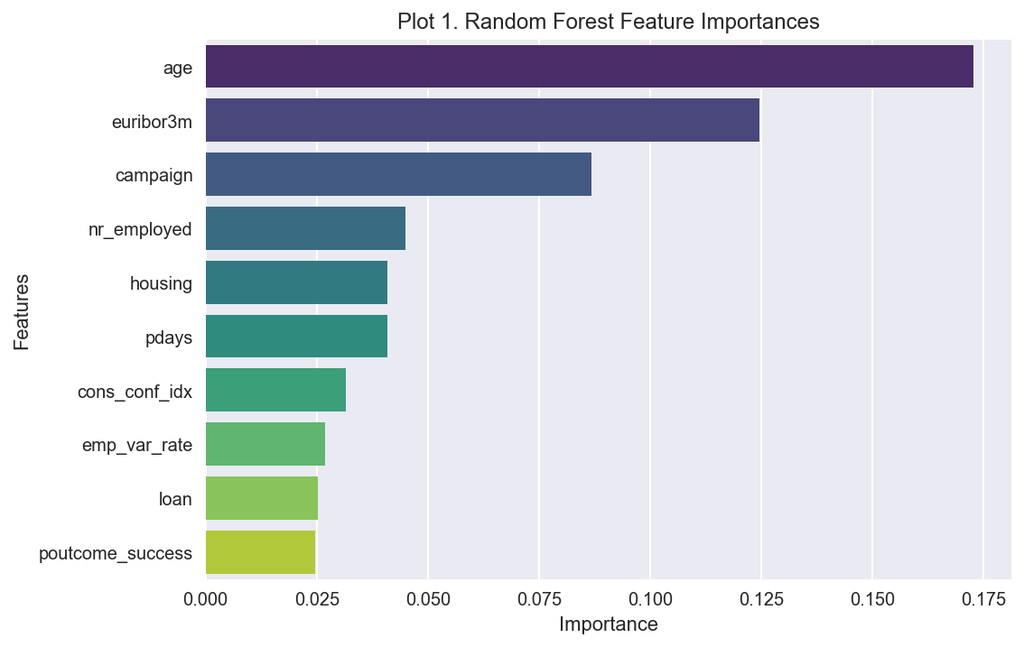

```python
# Plotting the importances
importances_plot(top_features_rfi, feature_importance_rfi,'Plot 1. Random Forest')
```

#### II. F-Score

Just like the Random Forest Importance Method, F-Score is also a filter based method. It returns a F-Score for each (depends upon the number of features selected) sorted from highest to the lowest (Feature Ranking, 2022).

```python
# Checking for F-Scores
from sklearn import feature_selection as fs

fs_fit_fscore = fs.SelectKBest(fs.f_classif, k = number_features)
fs_fit_fscore.fit_transform(data,target)
fs_indices_fscore = np.argsort(np.nan_to_num(fs_fit_fscore.scores_))[::-1][0:number_features]

print(f"Indices are {fs_indices_fscore}")

top_features_fscore = data_copy.columns[fs_indices_fscore].values
top_features_fscore
```

```
Indices are [12  6 51 11  8  7 50 39  4 42]
```

```
array(['nr_employed', 'pdays', 'poutcome_success', 'euribor3m',
       'emp_var_rate', 'previous', 'poutcome_nonexistent', 'month_mar',
       'contact', 'month_oct'], dtype=object)
```

```python
# Getting the importances of the features
fscore_importances = fs_fit_fscore.scores_[fs_indices_fscore]
fscore_importances
```

```
array([4662.47795071, 3666.92572574, 3479.06087646, 3378.24923921,
       3134.57310468, 1674.21771511, 1161.9716515 ,  666.63430354,
        644.21649876,  623.21535158])
```

As we can infer from the results that, being a filter based method, F-Score produced five different features than the Random Forest Importance method.

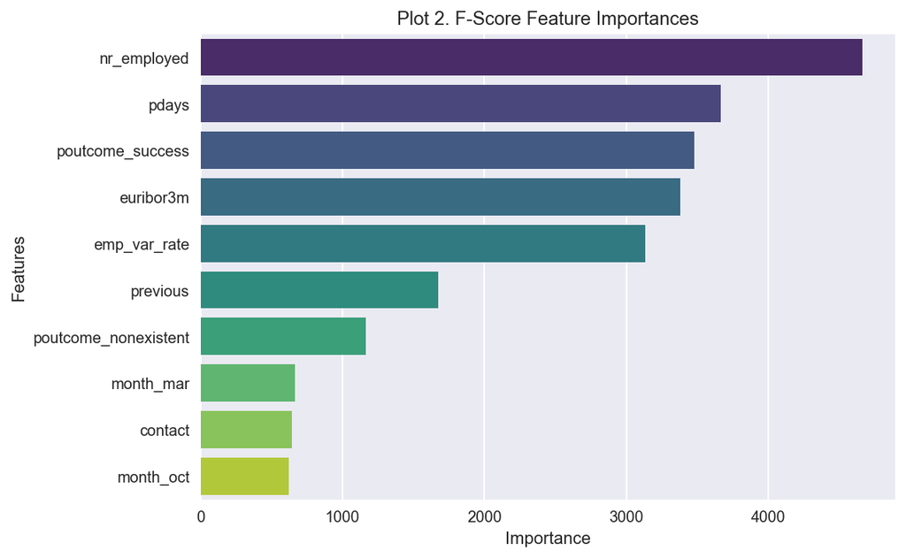

```python
# Plotting the importances
importances_plot(top_features_fscore, fscore_importances,'Plot 2. F-Score')
```

### Model Fitting and Tuning

Before we proceed towards Model Fitting and Hyper-Parameter tuning, we will perform a random selection of 5000 observations (considering the limitations of this machine) and use 70:30 split for the training and the test data-set.

```python
# Sampling data

data_sample = pd.DataFrame(data).sample(n=5000, random_state=999).values
target_sample = pd.DataFrame(target).sample(n=5000, random_state=999).values
```

To confirm if the above sampling has taken place, we will check the shape of the samples.

```python
# Checking the dimensions of the data-set
print(data_sample.shape)
print(target_sample.shape)
```

```
(5000, 52)
(5000, 1)
```

As we can observe that both the `data` and `target` arrays now have 5000 observations with 52 and 1 column(s) respectively. Now, we can proceed towards splitting our data into training and testing data-sets.

```python
# Performing train-test split
from sklearn.model_selection import train_test_split

d_train,d_test,t_train,t_test = train_test_split(data_sample,target_sample, test_size=0.3,random_state=999,stratify=target_sample)

print(d_train.shape)
print(d_test.shape)
print(t_train.shape)
print(t_test.shape)
```

```
(3500, 52)
(1500, 52)
(3500, 1)
(1500, 1)
```

From the above output, we can state that our data-sets have been divided into 70% and 30% for traning and testing respectively, and now we can continue towards finding the optimal hyperparameters for each fitted model.

For the **hyper-parameters tuning** task, we will use the 5 fold cross validation via the `StratifiedKFold` method. We are not performing any repeats because of the limitations of the machine at-hand, as the number of fits and the computational time would drastically increase in the below used algorithms.

```python
# Initializing Cross Validation Variable

from sklearn.model_selection import GridSearchCV, StratifiedKFold
cv_method = StratifiedKFold(n_splits=5,shuffle= True, random_state=999)
```

We will now "fit" different algorithms to our training data-sets.

#### 1. KNN Hyperparameter Tuning and Visualization

For K-Nearest Neighbors Algorithm there are two hyperparameters namely `k (number of neighbors)` and `p (type of distance metric)`. But, for this and for the following algorithms, we will also fine tune the number of features along with the hyperparameters. Earlier, we performed feature selection using Random Forest Importance and F-Score, similarly, we will do the same for the fine tuning process by passing the Random Forest Importance (we could also use SelectKBest() ) as a function under steps of a `Pipeline`.

We will be performing the below steps using 100 estimators. Additionally, the same would be used for the Decision Tree Classifier Algorithm, the Naive Bayes Algorithm, and on the Logistic Regressor as well.

Being a classification problem, and that too a binary one, we will use the scoring metric as `roc_auc` , because the problem at-hand is a highly imbalanced one. Alternatively, we could have also used **class weights** as a step in the pipeline to counter the imbalance.

**Note**: The following function is sourced from the Practice SK5 Solutions tutorial (Akman, 2022).

```python
from sklearn.base import BaseEstimator, TransformerMixin
from sklearn.ensemble import RandomForestClassifier
from numpy import argsort

# Creating a class for the Random Forest Classifier
class RFIFeatureSelector(BaseEstimator, TransformerMixin):

    # Defining Constructors of the class
    def __init__(self, n_features_=10):
        self.n_features_ = n_features_
        self.fs_indices_ = None
        self.fs_importance_ = None

    # This overrides the 'fit' function
    def fit(self, X, y):
        model_rfi = RandomForestClassifier(n_estimators=100, random_state=999)
        model_rfi.fit(X, y)
        self.fs_indices_ = argsort(model_rfi.feature_importances_)[::-1][0:self.n_features_]
        self.fs_importance_ = model_rfi.feature_importances_[self.fs_indices_ ]
        return self

    # This overrides the 'transform' function
    def transform(self, X, y=None):
        return X[:, self.fs_indices_]
```

We will now implement our `Pipeline` for the K-Nearest Neighbor Algorithm. The above `class` is being called through the steps of the `Pipeline`. We are also considering parallel processing via the usage of the argument `n_jobs = -2` in the `GridSearchCV` function.

**Note**: The total number of combinations would be 4 x 5 x 4 = 80 combinations.

```python
# Declaring the Pipeline

from sklearn.pipeline import Pipeline
from sklearn.neighbors import KNeighborsClassifier

pipe_KNN = Pipeline(steps=[('rfi_fs', RFIFeatureSelector()), #Call to the custom sourced function
                           ('knn', KNeighborsClassifier())])

params_pipe_KNN = {'rfi_fs__n_features_': [10, 20, 30, data.shape[1]],
                   'knn__n_neighbors': [1, 5, 10, 15, 20],
                   'knn__p': [1, 2, 3, 4]}

gs_pipe_KNN = GridSearchCV(estimator=pipe_KNN,
                           param_grid=params_pipe_KNN,
                           cv=cv_method,
                           refit=True,
                           n_jobs=-2,
                           scoring='roc_auc',
                           verbose=1)
```

We will now fit our training data into the above Grid Search variable `gs_pipe_KNN`.

```python
# Fitting the training data
gs_pipe_KNN.fit(d_train, t_train)
```

```
Fitting 5 folds for each of 80 candidates, totalling 400 fits
```

```
GridSearchCV(cv=StratifiedKFold(n_splits=5, random_state=999, shuffle=True),
             estimator=Pipeline(steps=[('rfi_fs', RFIFeatureSelector()),
                                       ('knn', KNeighborsClassifier())]),
             n_jobs=-2,
             param_grid={'knn__n_neighbors': [1, 5, 10, 15, 20],
                         'knn__p': [1, 2, 3, 4],
                         'rfi_fs__n_features_': [10, 20, 30, 52]},
             scoring='roc_auc', verbose=1)
```

```python
# Obtaining the best combination
gs_pipe_KNN.best_params_
```

```
{'knn__n_neighbors': 20, 'knn__p': 2, 'rfi_fs__n_features_': 10}
```

```python
# Obtaining the 'roc_auc' score the above best features
gs_pipe_KNN.best_score_
```

```
0.7780446644540698
```

From the outputs above, we can infer that the optimal KNN model has a mean `roc_auc` score of 0.778 approximately for 20 nearest neighbors, using the Euclidean Distance `p=2`, and 10 as the best number of features.

As a good measure of statistic, we will also check other combinations of results via the following function.

**Note**: The below function has been sourced from the Practice SK5 Tutorial (Akman, 2022).

```python
# Custom Function to get search results as a Pandas Data-frame

def get_search_results(gs):
    def model_result(scores, params):
        scores = {'mean_score': np.mean(scores),
             'std_score': np.std(scores), #Returns Standard Deviation
             'min_score': np.min(scores), #Returns the Minimum Score
             'max_score': np.max(scores)} #Returns the Maximum Score
        return pd.Series({**params,**scores})

    models = [] #Creating an empty list for the different models
    scores = [] #Creating an empty list for storing scores of different models

    for i in range(gs.n_splits_):
        key = f"split{i}_test_score"
        r = gs.cv_results_[key]
        scores.append(r.reshape(-1,1))
    all_scores = np.hstack(scores)

    for p, s in zip(gs.cv_results_['params'], all_scores):
        models.append((model_result(s, p)))

    pipe_results = pd.concat(models, axis=1).T.sort_values(['mean_score'], ascending=False)
    columns_first = ['mean_score', 'std_score', 'max_score', 'min_score']
    columns = columns_first + [c for c in pipe_results.columns if c not in columns_first]

    return pipe_results[columns]
```

```python
# Retrieving the pandas data-frame
results_KNN = get_search_results(gs_pipe_KNN)
results_KNN.head()
```

|  | mean_score | std_score | max_score | min_score | knn__n_neighbors | knn__p | rfi_fs__n_features_ |
| --- | --- | --- | --- | --- | --- | --- | --- |
| 68 | 0.778045 | 0.045757 | 0.827427 | 0.712878 | 20.0 | 2.0 | 10.0 |
| 76 | 0.777465 | 0.047836 | 0.827108 | 0.702012 | 20.0 | 4.0 | 10.0 |
| 72 | 0.776561 | 0.047125 | 0.823592 | 0.701309 | 20.0 | 3.0 | 10.0 |
| 64 | 0.775885 | 0.040333 | 0.810542 | 0.711284 | 20.0 | 1.0 | 10.0 |
| 52 | 0.774499 | 0.043567 | 0.815848 | 0.711284 | 15.0 | 2.0 | 10.0 |

As we can infer from the above data-frame, the 'best' combination was not significantly different from the other top 4 values. We will now visualize the results of the `GridSearchCV` using the `number of features = 10` as it was the best number of features.

```python
# Setting the number of features to 10
results_KNN_10_features = results_KNN[results_KNN['rfi_fs__n_features_'] == 10.0]
```

We will create a "for" loop that will iterate over the number of `knn__p` values uniquely that we had declared in the above function against the number of features set to 10.

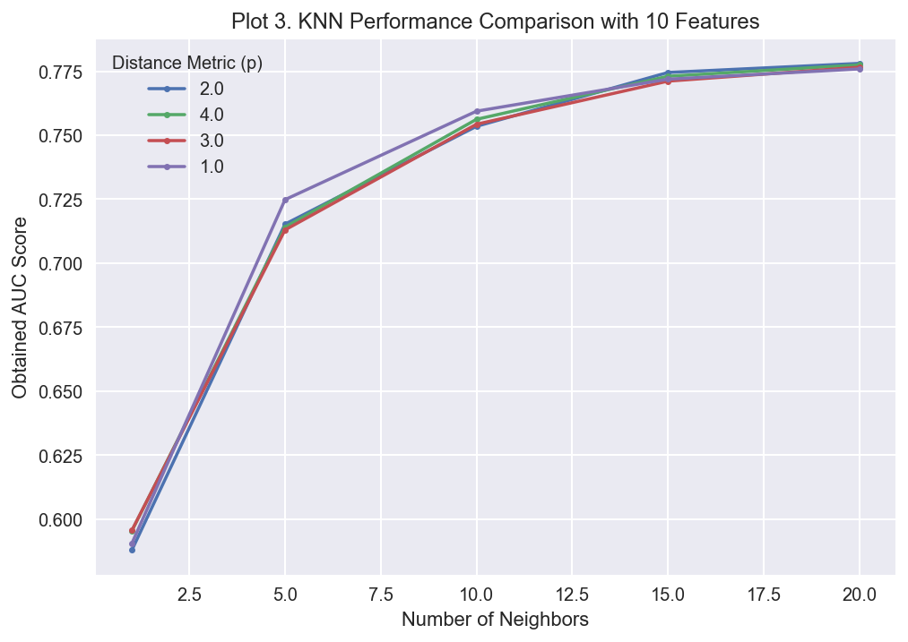

```python
# To iterate over different values of p
for i in results_KNN_10_features['knn__p'].unique():
    temp = results_KNN_10_features[results_KNN_10_features['knn__p'] == i]
    plt.plot(temp['knn__n_neighbors'], temp['mean_score'], marker = '.', label = i)

plt.legend(title = "Distance Metric (p)")
plt.xlabel('Number of Neighbors')
plt.ylabel("Obtained AUC Score")
plt.title("Plot 3. KNN Performance Comparison with 10 Features")
plt.show()
```

We can observe from the above curve that the plot was still increasing, and 20 may not have had been the best number of nearest neighbors, we will re-run the above algorithm below as a repeat, with increased number of neighbors.

```python
# Re-run of the Pipeline with increased neighbors

from sklearn.pipeline import Pipeline
from sklearn.neighbors import KNeighborsClassifier

pipe_KNN_2 = Pipeline(steps=[('rfi_fs', RFIFeatureSelector()), #Call to the custom sourced function
                           ('knn', KNeighborsClassifier())])

params_pipe_KNN_2 = {'rfi_fs__n_features_': [10, 20, 30, data.shape[1]],
                   'knn__n_neighbors': [30,40,100,150,200],
                   'knn__p': [1, 2, 3, 4]}

gs_pipe_KNN_2 = GridSearchCV(estimator=pipe_KNN_2,
                           param_grid=params_pipe_KNN_2,
                           cv=cv_method,
                           refit=True,
                           n_jobs=-2,
                           scoring='roc_auc',
                           verbose=1)
```

```python
# Fitting the training data
gs_pipe_KNN_2.fit(d_train, t_train)
```

```
Fitting 5 folds for each of 80 candidates, totalling 400 fits
```

```
GridSearchCV(cv=StratifiedKFold(n_splits=5, random_state=999, shuffle=True),
             estimator=Pipeline(steps=[('rfi_fs', RFIFeatureSelector()),
                                       ('knn', KNeighborsClassifier())]),
             n_jobs=-2,
             param_grid={'knn__n_neighbors': [30, 40, 100, 150, 200],
                         'knn__p': [1, 2, 3, 4],
                         'rfi_fs__n_features_': [10, 20, 30, 52]},
             scoring='roc_auc', verbose=1)
```

```python
# Obtaining the best combination
gs_pipe_KNN_2.best_params_
```

```
{'knn__n_neighbors': 100, 'knn__p': 1, 'rfi_fs__n_features_': 52}
```

```python
# Obtaining the best score
gs_pipe_KNN_2.best_score_
```

```
0.7906283399898746
```

We can note that the mean `roc_auc` score has increased to 0.790 approximately with the increase in the number of neighbors to 100, and that now the best measure of distance has changed to `p=1` from `p=2`, along with, the number of features to the entire set of 52.

Let us also visualize our graph to check if there are any more changes needed.

```python
# Saving the results
results_KNN_2 = get_search_results(gs_pipe_KNN_2)

# Setting the number of features to 10
results_KNN_52_features_2 = results_KNN_2[results_KNN_2['rfi_fs__n_features_'] == 52.0]
```

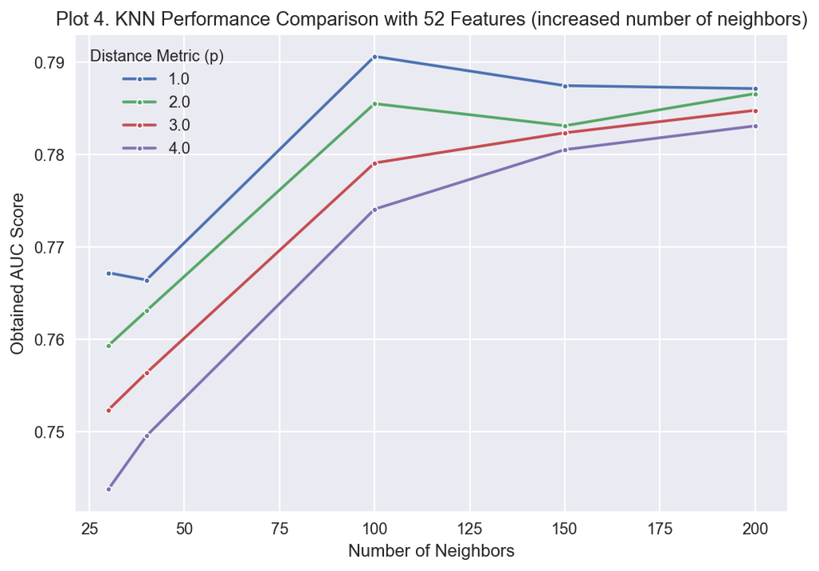

```python
# To iterate over different values of p
for i in results_KNN_52_features_2['knn__p'].unique():
    temp = results_KNN_52_features_2[results_KNN_52_features_2['knn__p'] == i]
    sns.lineplot(temp['knn__n_neighbors'], temp['mean_score'], marker = '.', label = i)

plt.legend(title = "Distance Metric (p)")
plt.xlabel('Number of Neighbors')
plt.ylabel("Obtained AUC Score")
plt.title("Plot 4. KNN Performance Comparison with 52 Features (increased number of neighbors)")
plt.show()
```

```python
# Re-run of the Pipeline without the entire set of features

from sklearn.pipeline import Pipeline
from sklearn.neighbors import KNeighborsClassifier

pipe_KNN_3 = Pipeline(steps=[('rfi_fs', RFIFeatureSelector()), #Call to the custom sourced function
                           ('knn', KNeighborsClassifier())])

params_pipe_KNN_3 = {'rfi_fs__n_features_': [10, 20, 30],
                   'knn__n_neighbors': [100,200,400],
                   'knn__p': [1, 2, 3, 4]}

gs_pipe_KNN_3 = GridSearchCV(estimator=pipe_KNN_3,
                           param_grid=params_pipe_KNN_3,
                           cv=cv_method,
                           refit=True,
                           n_jobs=-2,
                           scoring='roc_auc',
                           verbose=1)
```

```python
# Fitting the model
gs_pipe_KNN_3.fit(d_train,t_train)
```

```
Fitting 5 folds for each of 36 candidates, totalling 180 fits
```

```
GridSearchCV(cv=StratifiedKFold(n_splits=5, random_state=999, shuffle=True),
             estimator=Pipeline(steps=[('rfi_fs', RFIFeatureSelector()),
                                       ('knn', KNeighborsClassifier())]),
             n_jobs=-2,
             param_grid={'knn__n_neighbors': [100, 200, 400],
                         'knn__p': [1, 2, 3, 4],
                         'rfi_fs__n_features_': [10, 20, 30]},
             scoring='roc_auc', verbose=1)
```

Before we proceed further let us save our "Best Estimator" in a pickle file so that it can be obtained again.

```python
# Obtaining the best parameters
gs_pipe_KNN_3.best_params_
```

```
{'knn__n_neighbors': 200, 'knn__p': 1, 'rfi_fs__n_features_': 10}
```

```python
# Obtaining the best score
gs_pipe_KNN_3.best_score_
```

```
0.7826311151112861
```

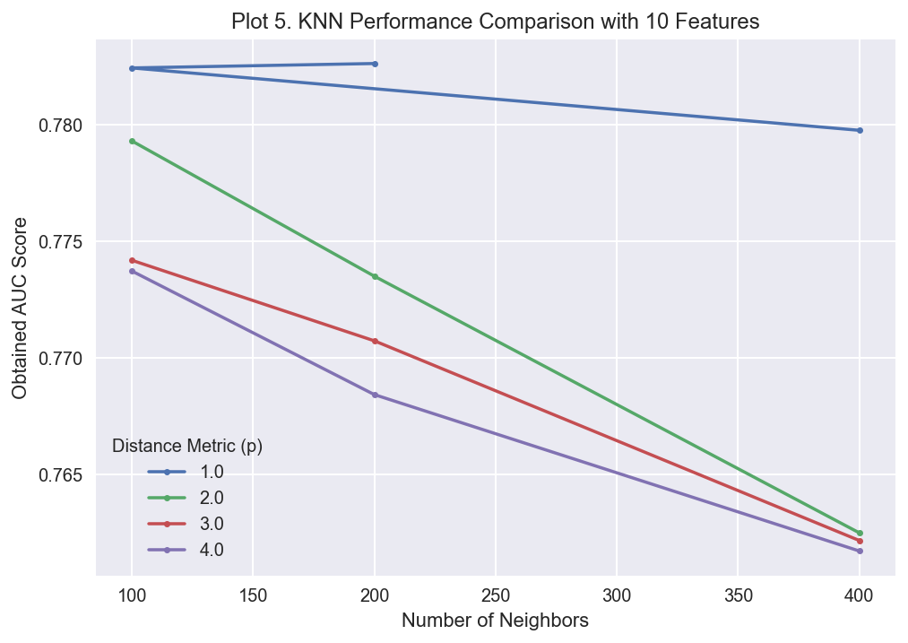

```python
# Saving the results
results_KNN_3 = get_search_results(gs_pipe_KNN_3)

# Setting the number of features to 10
results_KNN_10_features_2 = results_KNN_3[results_KNN_3['rfi_fs__n_features_'] == 10.0]

# To iterate over different values of p
for i in results_KNN_10_features_2['knn__p'].unique():
    temp = results_KNN_10_features_2[results_KNN_10_features_2['knn__p'] == i]
    plt.plot(temp['knn__n_neighbors'], temp['mean_score'], marker = '.', label = i)

plt.legend(title = "Distance Metric (p)")
plt.xlabel('Number of Neighbors')
plt.ylabel("Obtained AUC Score")
plt.title("Plot 5. KNN Performance Comparison with 10 Features")
plt.show()
```

From the above plot, we can now confirm that overfitting may not have occured to a higher extent as it would have with 52 features. We can also observe the dip in performance after reaching 200 nearest neighbors. The `roc_auc` score has decreased from the previous attempt from 0.790 to 0.782, which is a relatively small price to pay for avoiding overfitting.

We can now save our best estimator in a pickle file.

```python
# Importing joblib
import joblib
joblib.dump(gs_pipe_KNN_3.best_estimator_, 'best_KNN_3.pkl', compress = 1)
```

```
['best_KNN_3.pkl']
```

Let us evaluate the performance of our algorithm on the test data-set as well.

```python
# Predicting the outcome
pred_KNN = gs_pipe_KNN_3.predict(d_test)
print(f'ROC_AUC score via KNN {metrics.roc_auc_score(t_test,pred_KNN)}')
```

```
ROC_AUC score via KNN 0.5206287597085499
```

We can observe that the `roc_auc` score when the algorithm performed on the test-data decreased considerably from 0.782 to 0.520. Let us visualize the ROC curve for this model by the following:

```python
# Calculating the prediction scores
t_prob_KNN = gs_pipe_KNN_3.predict_proba(d_test)
t_prob_KNN[0:15]
```

```
array([[0.995, 0.005],
       [0.655, 0.345],
       [0.985, 0.015],
       [0.925, 0.075],
       [0.945, 0.055],
       [0.96 , 0.04 ],
       [1.   , 0.   ],
       [0.865, 0.135],
       [0.92 , 0.08 ],
       [0.99 , 0.01 ],
       [0.91 , 0.09 ],
       [0.965, 0.035],
       [0.94 , 0.06 ],
       [0.94 , 0.06 ],
       [0.96 , 0.04 ]])
```

```python
# Getting the True Positive and False Positive rate
fpr, tpr, _ = metrics.roc_curve(t_test, t_prob_KNN[:, 1])
roc_auc = metrics.auc(fpr, tpr)
roc_auc
```

```
0.8179557774782003
```

```python
# Building a data-frame
df_KNN = pd.DataFrame({'FPR': fpr, 'TPR': tpr})
df_KNN.head()
```

|  | FPR | TPR |
| --- | --- | --- |
| 0 | 0.000000 | 0.000000 |
| 1 | 0.000000 | 0.016043 |
| 2 | 0.000000 | 0.026738 |
| 3 | 0.000000 | 0.037433 |
| 4 | 0.001523 | 0.042781 |

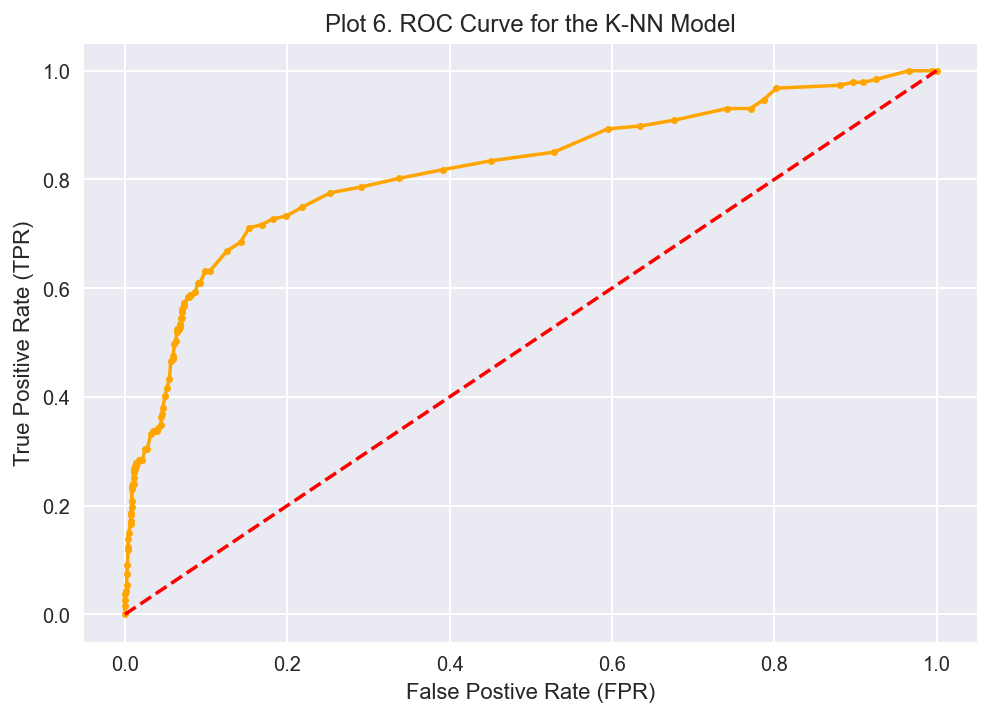

```python
# Plotting the ROC CURVE
ax_KNN = df_KNN.plot.line(x='FPR', y='TPR', title='Plot 6. ROC Curve for the K-NN Model', legend=False, marker = '.', color='orange')
plt.plot([0, 1], [0, 1], '--', color='red')
ax_KNN.set_xlabel("False Postive Rate (FPR)")
ax_KNN.set_ylabel("True Positive Rate (TPR)")
plt.show();
```

Our ROC curve is not the most perfectly fitting curve, and tells that our model may not have the best predictive performance capabilities. Also, higher the AUC (Area Under the Curve), higher will be the performance. In our case, the area is not so much, which is also evident from the `roc_auc` score of 0.817.

#### 2. Decision Tree Hyperparameter Tuning and Visualization

We will build a Decision Tree via using `gini_index` as a split criterion. In this algorithm, we want to find the optimal values for `max_depth` and `min_samples_split`. As stated earlier, we would be using the custom function of Random Forest Classifier in this Algorithm as well.

We will consider the `max_depth` values as {3,5,7,9,11} and `min_samples_split` values as {2,5,7,9,11,13}.

```python
# Setting the Pipeline for the Decision Tree Classifier
from sklearn.tree import DecisionTreeClassifier

pipe_DT = Pipeline([('rfi_fs', RFIFeatureSelector()),
                    ('dt', DecisionTreeClassifier(criterion='gini', random_state=999))])

params_pipe_DT = {'rfi_fs__n_features_': [10, 20, 30, data.shape[1]],
                  'dt__max_depth': [3, 5, 7, 9, 11],
                  'dt__min_samples_split': [2, 5, 7, 9, 11, 13]}

gs_pipe_DT = GridSearchCV(estimator=pipe_DT,
                          param_grid=params_pipe_DT,
                          cv=cv_method,
                          refit=True,
                          n_jobs=-2,
                          scoring='roc_auc',
                          verbose=1)
```

```python
# Fitting the training data into the Decision Tree Algorithm
gs_pipe_DT.fit(d_train, t_train)
```

```
Fitting 5 folds for each of 120 candidates, totalling 600 fits
```

```
GridSearchCV(cv=StratifiedKFold(n_splits=5, random_state=999, shuffle=True),
             estimator=Pipeline(steps=[('rfi_fs', RFIFeatureSelector()),
                                       ('dt',
                                        DecisionTreeClassifier(random_state=999))]),
             n_jobs=-2,
             param_grid={'dt__max_depth': [3, 5, 7, 9, 11],
                         'dt__min_samples_split': [2, 5, 7, 9, 11, 13],
                         'rfi_fs__n_features_': [10, 20, 30, 52]},
             scoring='roc_auc', verbose=1)
```

```python
# Obtaining the best parameters
gs_pipe_DT.best_params_
```

```
{'dt__max_depth': 5, 'dt__min_samples_split': 13, 'rfi_fs__n_features_': 52}
```

```python
# Obtaining the scoring metric for the best parameters
gs_pipe_DT.best_score_
```

```
0.7648140856162458
```

We can observe that the mean `roc_auc` for the Decision Tree Classifier came out to be 0.764 approximately with the optimal parameters of `max_depth=5`, `min_samples_split=13`, and quite interestingly it also considered the entire set of features. The score is slightly less than that was obtained using the K-NN model.

Like we performed above, we will check how much the difference was when considered with the other top values, for this, we will 'call' the custom function `get_search_results()`.

```python
# Fetching other top 4 search results
results_DT = get_search_results(gs_pipe_DT)
results_DT.head()
```

|  | mean_score | std_score | max_score | min_score | dt__max_depth | dt__min_samples_split | rfi_fs__n_features_ |
| --- | --- | --- | --- | --- | --- | --- | --- |
| 47 | 0.764814 | 0.042159 | 0.820573 | 0.693977 | 5.0 | 13.0 | 52.0 |
| 45 | 0.763772 | 0.044816 | 0.794032 | 0.675320 | 5.0 | 13.0 | 20.0 |
| 33 | 0.762639 | 0.045082 | 0.803763 | 0.675320 | 5.0 | 7.0 | 20.0 |
| 41 | 0.761928 | 0.043632 | 0.793038 | 0.675320 | 5.0 | 11.0 | 20.0 |
| 39 | 0.761480 | 0.044960 | 0.820573 | 0.684386 | 5.0 | 9.0 | 52.0 |

We can see that there are outcomes that have not used the entire set of features. Let us also visualize for different values of `max_depth`. The below code chunk is similar to one we performed for visualizing KNN Algorithm.

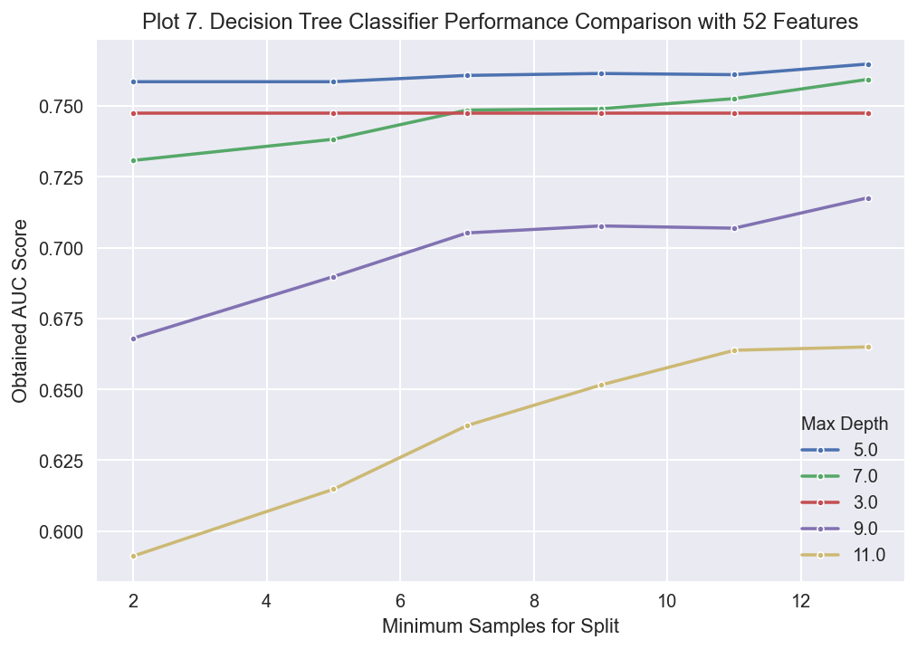

```python
# Setting the number of features to the best value of 1 (what we obtained)
results_DT_52_features = results_DT[results_DT['rfi_fs__n_features_'] == 52.0]

# For loop to iterate over the different 'max_depth' values
for i in results_DT_52_features['dt__max_depth'].unique():
    temp = results_DT_52_features[results_DT_52_features['dt__max_depth'] == i]
    sns.lineplot(temp['dt__min_samples_split'], temp['mean_score'], marker = '.', label = i)

plt.legend(title = "Max Depth")
plt.xlabel('Minimum Samples for Split')
plt.ylabel("Obtained AUC Score")
plt.title("Plot 7. Decision Tree Classifier Performance Comparison with 52 Features")
plt.show()
```

As we can infer for the value of `max_depth = 5` it reached a maximum at the value of `min_samples_split=13`, but after that, we cannot deduce anything about the performance of the algorith. Therefore, we need to re-run it to check where the improvement stops. Furthermore, we can observe that the plot of `max_depth=7` is constantly increasing with increased number of splits, and may also produce a slightly better mean `roc_auc` score. Additionally, we will not consider the entire set of features for this run to avoid over-fitting.

```python
# Re-Setting the Pipeline for the Decision Tree Classifier
from sklearn.tree import DecisionTreeClassifier

pipe_DT_2 = Pipeline([('rfi_fs', RFIFeatureSelector()),
                    ('dt', DecisionTreeClassifier(criterion='gini', random_state=999))])

params_pipe_DT_2 = {'rfi_fs__n_features_': [10, 20, 30],
                  'dt__max_depth': [5, 7, 9, 11],
                  'dt__min_samples_split': [13,100,200,400]}

gs_pipe_DT_2 = GridSearchCV(estimator=pipe_DT_2,
                          param_grid=params_pipe_DT_2,
                          cv=cv_method,
                          refit=True,
                          n_jobs=-2,
                          scoring='roc_auc',
                          verbose=1)
```

```python
gs_pipe_DT_2.fit(d_train,t_train)
```

```
Fitting 5 folds for each of 48 candidates, totalling 240 fits
```

```
GridSearchCV(cv=StratifiedKFold(n_splits=5, random_state=999, shuffle=True),
             estimator=Pipeline(steps=[('rfi_fs', RFIFeatureSelector()),
                                       ('dt',
                                        DecisionTreeClassifier(random_state=999))]),
             n_jobs=-2,
             param_grid={'dt__max_depth': [5, 7, 9, 11],
                         'dt__min_samples_split': [13, 100, 200, 400],
                         'rfi_fs__n_features_': [10, 20, 30]},
             scoring='roc_auc', verbose=1)
```

```python
# Obtaining the best parameters
gs_pipe_DT_2.best_params_
```

```
{'dt__max_depth': 7, 'dt__min_samples_split': 200, 'rfi_fs__n_features_': 10}
```

```python
# Obtaining the best score
gs_pipe_DT_2.best_score_
```

```
0.7983255517428888
```

The score obtained is now slightly higher that was obtained earlier, and the one that was obtained using the K-NN model. Let us also check for other top values.

```python
# Fetching other top 4 search results
results_DT_2 = get_search_results(gs_pipe_DT_2)
results_DT_2.head()
```

|  | mean_score | std_score | max_score | min_score | dt__max_depth | dt__min_samples_split | rfi_fs__n_features_ |
| --- | --- | --- | --- | --- | --- | --- | --- |
| 18 | 0.798326 | 0.034635 | 0.830539 | 0.732913 | 7.0 | 200.0 | 10.0 |
| 20 | 0.797810 | 0.028191 | 0.822205 | 0.744051 | 7.0 | 200.0 | 30.0 |
| 42 | 0.797261 | 0.046392 | 0.839165 | 0.707543 | 11.0 | 200.0 | 10.0 |
| 30 | 0.795740 | 0.044968 | 0.840806 | 0.716403 | 9.0 | 200.0 | 10.0 |
| 19 | 0.795273 | 0.032467 | 0.819055 | 0.732913 | 7.0 | 200.0 | 20.0 |

As expected there is not much difference between the other values, but 3 out of the 5 have selected the top 10 features for deducing purposes. Let us now visualize our results.

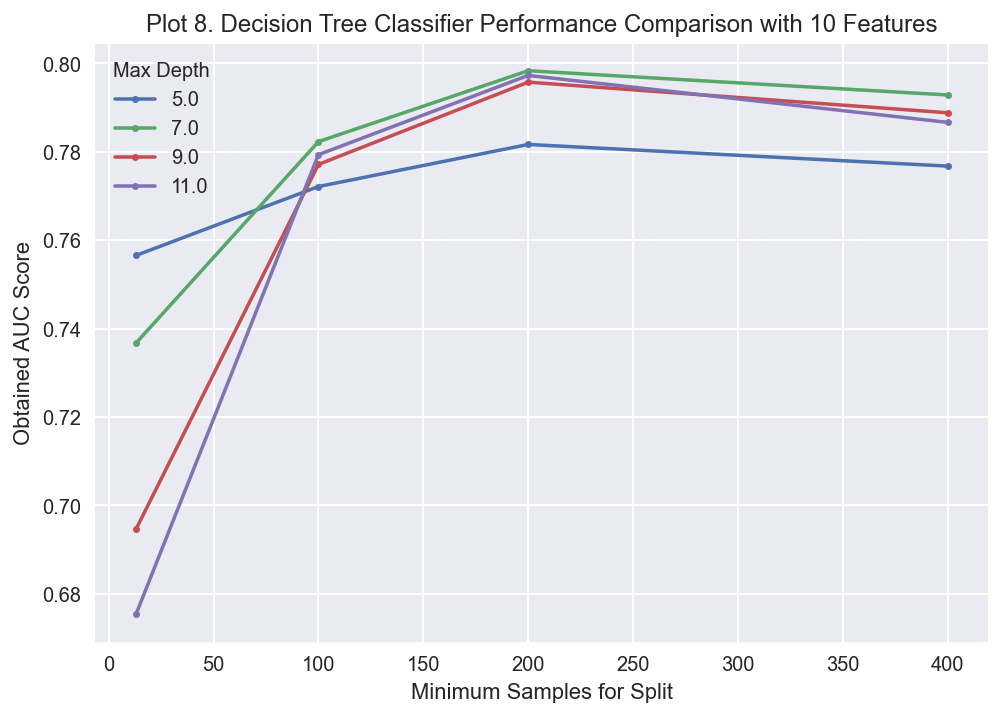

```python
# Setting the number of features to the best value of 10 (what we obtained)
results_DT_10_features = results_DT_2[results_DT_2['rfi_fs__n_features_'] == 10.0].sort_values('dt__min_samples_split')

# For loop to iterate over the different 'max_depth' values
for i in results_DT_10_features['dt__max_depth'].unique():
    temp = results_DT_10_features[results_DT_10_features['dt__max_depth'] == i]
    plt.plot(temp['dt__min_samples_split'], temp['mean_score'], marker = '.', label = i)

plt.legend(title = "Max Depth")
plt.xlabel('Minimum Samples for Split')
plt.ylabel("Obtained AUC Score")
plt.title("Plot 8. Decision Tree Classifier Performance Comparison with 10 Features")
plt.show()
```

The above plot seems to be an ideal representation of the performance, as we can clearly observe the **elbow-shape** in each curve, indicative of the decrease in performance after having reached a maximum. Let us check the prediction on the test-data as well.

```python
# Calculating for Decision Tree
pred_DT = gs_pipe_DT_2.predict(d_test)
print(f'ROC_AUC score via DT {metrics.roc_auc_score(t_test,pred_DT)}')
```

```
ROC_AUC score via DT 0.668870733227169
```

The `roc_auc` score obtained on the test data is 0.668 approximately, which is again less than that obtained on the train-data. We will now visualize the ROC curve for our Decision Tree model as well.

```python
# Calculating probabilities
t_prob_DT = gs_pipe_DT_2.predict_proba(d_test)
t_prob_DT[0:15]
```

```
array([[0.96571906, 0.03428094],
       [0.79824561, 0.20175439],
       [0.96571906, 0.03428094],
       [0.96571906, 0.03428094],
       [0.96571906, 0.03428094],
       [0.96571906, 0.03428094],
       [0.99283154, 0.00716846],
       [0.83248731, 0.16751269],
       [0.91354167, 0.08645833],
       [0.96571906, 0.03428094],
       [0.91354167, 0.08645833],
       [0.96571906, 0.03428094],
       [0.91354167, 0.08645833],
       [0.96571906, 0.03428094],
       [0.96571906, 0.03428094]])
```

```python
# Calculating parameters for the ROC curve
fpr_DT, tpr_DT, _ = metrics.roc_curve(t_test, t_prob_DT[:, 1])
roc_auc = metrics.auc(fpr_DT, tpr_DT)
roc_auc
```

```
0.8095006333212508
```

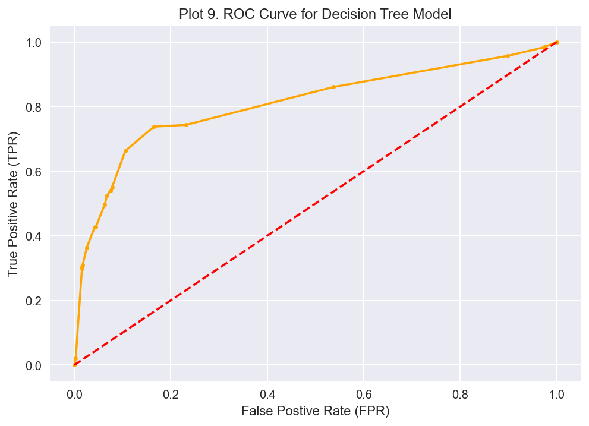

```python
# Plotting the ROC
df_DT = pd.DataFrame({'FPR': fpr_DT, 'TPR': tpr_DT})

ax_DT = df_DT.plot.line(x='FPR', y='TPR', title='Plot 9. ROC Curve for Decision Tree Model', legend=False, marker = '.',color='orange')
plt.plot([0, 1], [0, 1], '--',color='red')
ax_DT.set_xlabel("False Postive Rate (FPR)")
ax_DT.set_ylabel("True Positive Rate (TPR)")
plt.show();
```

The elbow for our Decision Tree Model is slightly lower than that of the K-NN model, which is also evident from the `roc_auc` score obtained using the False Positive Rate and the True Positive Rate. The score is lower for the Decision Tree Model than that of K-Nearest Neighbor.

We will save the results for the best estimator attained from the Decision Tree Classifier to a pickle file as well.

```python
# Importing joblib
import joblib
joblib.dump(gs_pipe_DT_2.best_estimator_, 'best_DT_2.pkl', compress = 1)
```

```
['best_DT_2.pkl']
```

#### 3. Gaussian Naive Bayes Hyperparameter Tuning and Visualization

One of the requirements of the Naive Bayes Algorithm is that it requires the features to have a normal distribution which usually is not the case, and to make valid that condition, we take the help of a power transformer, which is applied on the input data before we "fit" the model.

```python
# Using the Power Transformer
from sklearn.preprocessing import PowerTransformer
d_train_transformed = PowerTransformer().fit_transform(d_train)
```

Now we can go about "fitting" our model on the transformed data-set `d_train_transformed`. For the `var_smoothing` hyperparameter, we will be using the values from 1 to -3 with 80 different values in-between (including extreme values), as the number of fits increases drastically with increased number of values. Furthermore, we will not be considering the entire set of features.

```python
from sklearn.naive_bayes import GaussianNB

pipe_NB = Pipeline([('rfi_fs', RFIFeatureSelector()),
                     ('nb', GaussianNB())])

params_pipe_NB = {'rfi_fs__n_features_': [10, 20, 30],
                  'nb__var_smoothing': np.logspace(1,-3, num=80)}

gs_pipe_NB = GridSearchCV(estimator=pipe_NB,
                          param_grid=params_pipe_NB,
                          cv=cv_method,
                          refit=True,
                          n_jobs=-2,
                          scoring='roc_auc',
                          verbose=1)
```

```python
# Fitting the model
gs_pipe_NB.fit(d_train_transformed,t_train)
```

```
Fitting 5 folds for each of 240 candidates, totalling 1200 fits
```

```
GridSearchCV(cv=StratifiedKFold(n_splits=5, random_state=999, shuffle=True),
             estimator=Pipeline(steps=[('rfi_fs', RFIFeatureSelector()),
                                       ('nb', GaussianNB())]),
             n_jobs=-2,
             param_grid={'nb__var_smoothing': array([1.00000000e+01, 8.89953035e+00, 7.92016405e+00, 7.04857404e+00,
       6.27289986e+00, 5.58258627e+00, 4.96823959e+00, 4.42149991e+00,
       3.93492726e+00, 3.50190046e+...
       9.16273901e-03, 8.15440740e-03, 7.25703961e-03, 6.45842443e-03,
       5.74769442e-03, 5.11517810e-03, 4.55226828e-03, 4.05130497e-03,
       3.60547115e-03, 3.20870000e-03, 2.85559230e-03, 2.54134304e-03,
       2.26167595e-03, 2.01278538e-03, 1.79128445e-03, 1.59415904e-03,
       1.41872667e-03, 1.26260011e-03, 1.12365480e-03, 1.00000000e-03]),
                         'rfi_fs__n_features_': [10, 20, 30]},
             scoring='roc_auc', verbose=1)
```

```python
# Obtaining the optimal hyper parameters
gs_pipe_NB.best_params_
```

```
{'nb__var_smoothing': 0.0011236548001387517, 'rfi_fs__n_features_': 30}
```

```python
# Obtaining the mean 'roc_auc' score
gs_pipe_NB.best_score_
```

```
0.7579569106148394
```

The optimal Naive Bayes Algorithm yields a `roc_auc` score of 0.757 approximately. As of now it is the lowest as compared to the K-NN and the Decision Tree algorithm. Like we performed for the algorithms above, we will check the other top - 4 values as well.

```python
# Retrieving the other top-4 values
results_NB = get_search_results(gs_pipe_NB)
results_NB.head()
```

|  | mean_score | std_score | max_score | min_score | nb__var_smoothing | rfi_fs__n_features_ |
| --- | --- | --- | --- | --- | --- | --- |
| 236 | 0.757957 | 0.050518 | 0.796375 | 0.663620 | 0.001124 | 30.0 |
| 239 | 0.757953 | 0.050525 | 0.796357 | 0.663601 | 0.001000 | 30.0 |
| 233 | 0.757946 | 0.050530 | 0.796375 | 0.663582 | 0.001263 | 30.0 |
| 230 | 0.757942 | 0.050533 | 0.796375 | 0.663563 | 0.001419 | 30.0 |
| 227 | 0.757927 | 0.050553 | 0.796394 | 0.663526 | 0.001594 | 30.0 |

Just like the other algorithms, there is only a small difference between the values of `mean_score` with the same set of top-30 features.

We will now visualize the results.

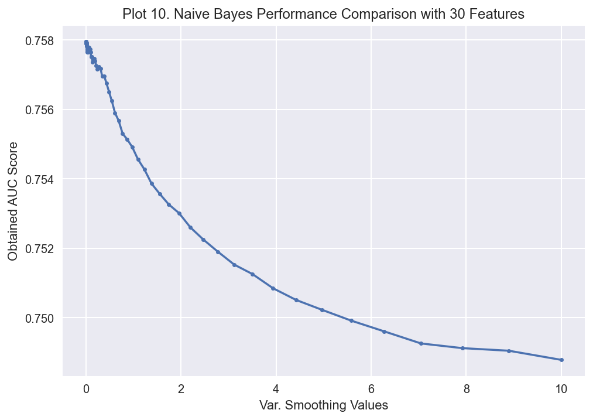

```python
# Visualizing the results and setting the number of features to 30
results_NB_30_features = results_NB[results_NB['rfi_fs__n_features_'] == 30.0].sort_values('nb__var_smoothing')

plt.plot(results_NB_30_features['nb__var_smoothing'], results_NB_30_features['mean_score'], marker = '.', label = i)
plt.xlabel('Var. Smoothing Values')
plt.ylabel("Obtained AUC Score")
plt.title("Plot 10. Naive Bayes Performance Comparison with 30 Features")
plt.show()
```

From the above plot, we can observe that the graph starts to decline from a `var. smoothing value` of 0 itself. The graph depicts an almost exponential drop in performance as the `var. smoothing values` increase.

```python
# Calculating for Naive Bayes
pred_NB = gs_pipe_NB.predict(d_test)
print(f'ROC_AUC score via NB {metrics.roc_auc_score(t_test,pred_NB)}')
```

```
ROC_AUC score via NB 0.5
```

We will now visualize the ROC curve as well.

```python
# Obtaining the roc_auc score using probabilities
t_prob_NB = gs_pipe_NB.predict_proba(d_test)
fpr_NB, tpr_NB, _ = metrics.roc_curve(t_test, t_prob_NB[:, 1])
roc_auc = metrics.auc(fpr_NB, tpr_NB)
roc_auc
```

```
0.803967727089451
```

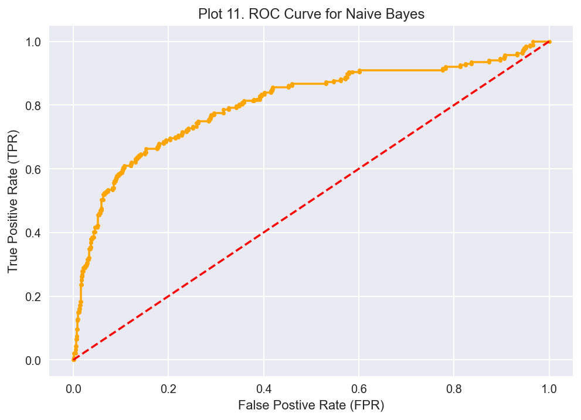

```python
# Visualizing the ROC curve
df_NB = pd.DataFrame({'FPR': fpr_NB, 'TPR': tpr_NB})

ax_NB = df_NB.plot.line(x='FPR', y='TPR', title='Plot 11. ROC Curve for Naive Bayes', legend=False, marker = '.',color='orange')
plt.plot([0, 1], [0, 1], '--',color='red')
ax_NB.set_xlabel("False Postive Rate (FPR)")
ax_NB.set_ylabel("True Positive Rate (TPR)")
plt.show();
```

Although a bit different because of the representation of the sharp edges, the curve is very similar to what we obtained for Decision Tree, whcih is also evident from the approximately similar scores.

We can now say the details of our best estimator into a pickle file.

```python
# Importing joblib
import joblib
joblib.dump(gs_pipe_NB.best_estimator_, 'best_NB.pkl', compress = 1)
```

```
['best_NB.pkl']
```

#### 4. Logistic Regression Hypertuning and Visualization

Although this particular algorithm does not have any critical hyperparameters to tune, but variation in performance can be observed by using different *solvers*. Regularization in this algorithm becomes important, and it is done by the use of `penalty`. But not all penalties are supported by different solvers, since, 'l2' is the most common, therefore, we shall be using only this for tuning purposes (Scikit-Learn, 2022).

```python
from sklearn.pipeline import Pipeline
from sklearn.linear_model import LogisticRegression

pipe_LR = Pipeline(steps=[('rfi_fs', RFIFeatureSelector()), #Call to the custom sourced function
                           ('LR', LogisticRegression())])

params_pipe_LR = {'rfi_fs__n_features_': [10, 20, 30],
                   'LR__C': [100,10,1.0,0.1,0.01], #Smaller values will provide a stronger regularization
                   'LR__penalty': ['l2'],
                    'LR__solver': ['newton-cg','lbfgs','liblinear','saga']
                    }

gs_pipe_LR = GridSearchCV(estimator=pipe_LR,
                           param_grid=params_pipe_LR,
                           cv=cv_method,
                           refit=True,
                           n_jobs=-2,
                           scoring='roc_auc',
                           verbose=1)
```

```python
gs_pipe_LR.fit(d_train,t_train)
```

```
Fitting 5 folds for each of 60 candidates, totalling 300 fits
```

```
GridSearchCV(cv=StratifiedKFold(n_splits=5, random_state=999, shuffle=True),
             estimator=Pipeline(steps=[('rfi_fs', RFIFeatureSelector()),
                                       ('LR', LogisticRegression())]),
             n_jobs=-2,
             param_grid={'LR__C': [100, 10, 1.0, 0.1, 0.01],
                         'LR__penalty': ['l2'],
                         'LR__solver': ['newton-cg', 'lbfgs', 'liblinear',
                                        'saga'],
                         'rfi_fs__n_features_': [10, 20, 30]},
             scoring='roc_auc', verbose=1)
```

```python
# Fetching the best parameters
gs_pipe_LR.best_params_
```

```
{'LR__C': 1.0,
 'LR__penalty': 'l2',
 'LR__solver': 'liblinear',
 'rfi_fs__n_features_': 30}
```

```python
# Fetching the best score
gs_pipe_LR.best_score_
```

```
0.7833380210384204
```

We can note that the Logistic Regression Classifier also considered the top 30 features like the Naive Bayes Algorithm, with the solver `liblinear`, providing us with the mean `roc_auc` score of 0.783 approximately, which is higher than that was obtained by the Naive Bayes model. We will now check for the other top observations.

```python
# Retrieving the other top-4 values
results_LR = get_search_results(gs_pipe_LR)
results_LR.head()
```

|  | mean_score | std_score | max_score | min_score | LR__C | LR__penalty | LR__solver | rfi_fs__n_features_ |
| --- | --- | --- | --- | --- | --- | --- | --- | --- |
| 32 | 0.783338 | 0.050285 | 0.828074 | 0.697015 | 1.0 | l2 | liblinear | 30 |
| 29 | 0.783192 | 0.050409 | 0.827999 | 0.697034 | 1.0 | l2 | lbfgs | 30 |
| 35 | 0.783184 | 0.050394 | 0.82798 | 0.697052 | 1.0 | l2 | saga | 30 |
| 26 | 0.783181 | 0.050401 | 0.82798 | 0.697034 | 1.0 | l2 | newton-cg | 30 |
| 20 | 0.78204 | 0.049331 | 0.83143 | 0.702565 | 10 | l2 | liblinear | 30 |

One definite point to be observed is that all the solvers had the approximately the same `mean_score`, and all had considered top 30 as their best set of features. We can now move towards, plotting the curve.

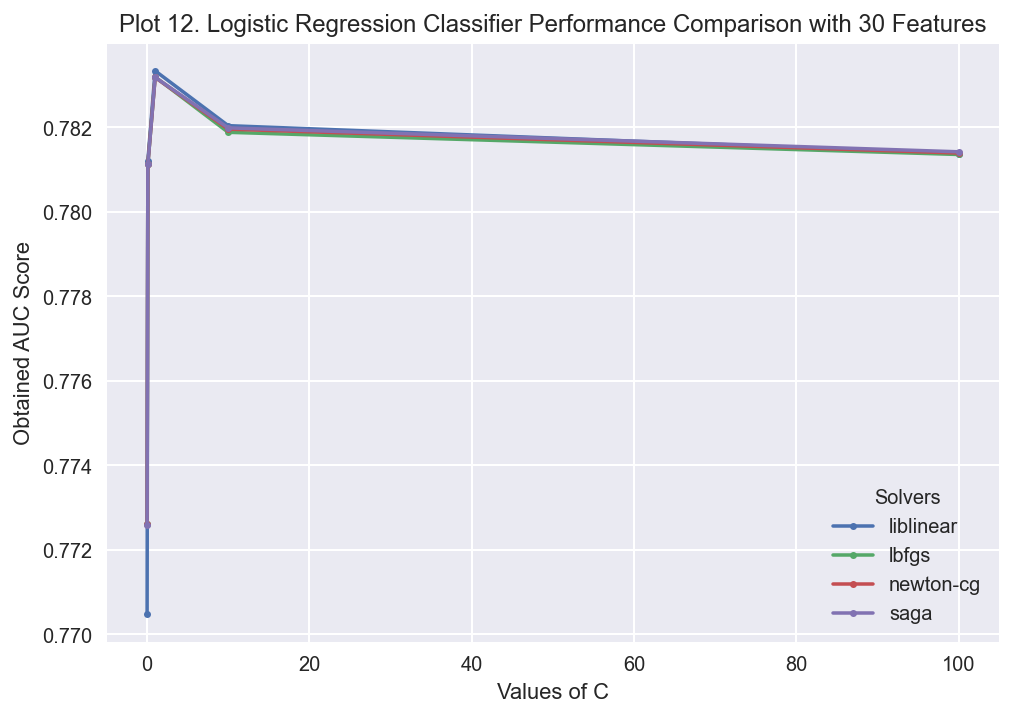

```python
# Setting the number of features to the best value of 30 (what we obtained)
results_LR_30_features = results_LR[results_LR['rfi_fs__n_features_'] == 30.0].sort_values('LR__C')

# For loop to iterate over the different 'max_depth' values
for i in results_LR_30_features['LR__solver'].unique():
    temp = results_LR_30_features[results_LR_30_features['LR__solver'] == i]
    plt.plot(temp['LR__C'], temp['mean_score'], marker = '.', label = i)

plt.legend(title = "Solvers")
plt.xlabel('Values of C')
plt.ylabel("Obtained AUC Score")
plt.title("Plot 12. Logistic Regression Classifier Performance Comparison with 30 Features")
plt.show()
```

We can clearly observe the **elbow-shape** on the curves, which depicts the depreciating performance after having reached the maximum performance at the value of `C = 1.0`.

```python
# Calculating for Logistic Regressor
pred_LR = gs_pipe_LR.predict(d_test)
print(f'ROC_AUC score via LR {metrics.roc_auc_score(t_test,pred_LR)}')
```

```
ROC_AUC score via LR 0.6417438123902888
```

```python
# Calculating probability
t_prob_LR = gs_pipe_LR.predict_proba(d_test)
```

```python
fpr_LR, tpr_LR, _ = metrics.roc_curve(t_test, t_prob_LR[:, 1])
roc_auc_LR = metrics.auc(fpr_LR, tpr_LR)
roc_auc_LR
```

```
0.8077228537333371
```

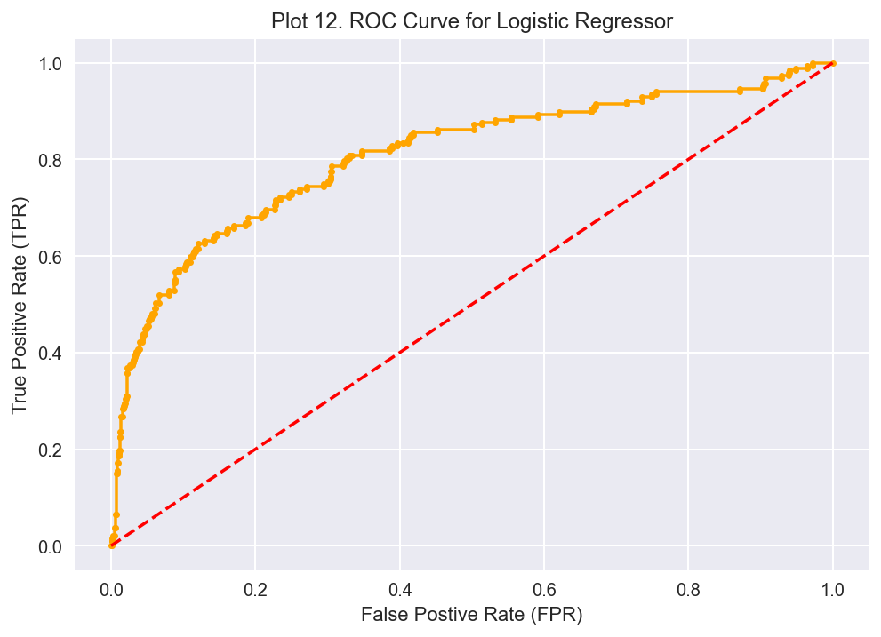

```python
# Plotting the ROC CURVE
df_LR = pd.DataFrame({'FPR': fpr_LR, 'TPR': tpr_LR})
ax_LR = df_LR.plot.line(x='FPR', y='TPR', title='Plot 12. ROC Curve for Logistic Regressor', legend=False, marker = '.',color='orange')
plt.plot([0, 1], [0, 1], '--', color='red')
ax_LR.set_xlabel("False Postive Rate (FPR)")
ax_LR.set_ylabel("True Positive Rate (TPR)")
plt.show();
```

Almost a very similar curve to the other algorithms, but the score obtained using the False Positive Rate and the True Positive Rate is slightly higher than that of Naive Bayes, with K-NN having the highest score using the same formulae.

Saving the best estimator into a pickle file for retrieval later.

```python
# Importing joblib
import joblib
joblib.dump(gs_pipe_LR.best_estimator_, 'best_LR.pkl', compress = 1)
```

```
['best_LR.pkl']
```

### Model Comparison

One of the most important steps in Machine Learning is the **Model Comparison**, ideally, because we want to find out the "Best" model for our needs, and also how the model will perform when deployed. But, there are two major considerations to keep in mind for evaluation; how the data is split, and what metric is to be used for evalutaion ?

In our case (as performed above), we had used a 5-Fold Cross Validation process and deployed it to each of our algorithms. Regarding what metric is to be used, we had used the scoring metric as `roc_auc`, because the problem at-hand is a classification problem, the target-feature is binary, and we have a class-imbalance to tackle as well. Therefore, `roc_auc` is the perfect fit for this type of a problem.

To find out the best model, we will use the paired *t-test* statistical test. Before doing so, we need to see the performance evaluation of our algorithms via the `cross_val_score` , but this time, we will use 5 fold cross validation with 2 repetitions on each tuned classifiers. After which, we shall conduct the statistical significance test on the following combinations:

1. KNN v. DT,
2. KNN v. NB,
3. KNN v. LR,
4. DT v. NB,
5. DT v. LR, and
6. NB v. LR

Now, we will calculate the mean `cross_val_score`for each Classifier using their respective best estimator.

```python
# Importing necessary packages
from sklearn.model_selection import cross_val_score, RepeatedStratifiedKFold

cv_method_t_test = RepeatedStratifiedKFold(n_splits=5, n_repeats = 2, random_state=999)

cv_results_KNN = cross_val_score(estimator=gs_pipe_KNN_3.best_estimator_,
                                 X=d_test,
                                 y=t_test,
                                 cv=cv_method_t_test,
                                 n_jobs=-2,
                                 scoring='roc_auc')
# Obtaining the mean roc_auc score
cv_results_KNN.mean()
```

```
0.8042380302330357
```

```python
# Performing for Decision Tree
cv_results_DT = cross_val_score(estimator=gs_pipe_DT_2.best_estimator_,
                                 X=d_test,
                                 y=t_test,
                                 cv=cv_method_t_test,
                                 n_jobs=-2,
                                 scoring='roc_auc')

# Obtaining the mean roc_auc score
cv_results_DT.mean()
```

```
0.7885909645642967
```

```python
# Performing for Naive Bayes

# Power Transforming the descriptive test data-set
d_test_transformed = PowerTransformer().fit_transform(d_test)

cv_results_NB = cross_val_score(estimator=gs_pipe_NB.best_estimator_,
                                 X=d_test,
                                 y=t_test,
                                 cv=cv_method_t_test,
                                 n_jobs=-2,
                                 scoring='roc_auc')

# Obtaining the mean roc_auc score
cv_results_NB.mean()
```

```
0.8116654256015543
```

```python
# Performing for Logistic Regressor
cv_results_LR = cross_val_score(estimator=gs_pipe_LR.best_estimator_,
                                 X=d_test,
                                 y=t_test,
                                 cv=cv_method_t_test,
                                 n_jobs=-2,
                                 scoring='roc_auc')

# Obtaining the mean roc_auc score
cv_results_LR.mean()
```

```
0.8199802767982224
```

Comparing the above 4 mean cross validation scores (`roc_auc`), we can observe that Logistic Regressor outperforms the other algorithms. But, a point to be noted is that the difference between the other values for the Logistic Regressor is very small. The score for the Logistic Regressor is 0.819 approximately, while for KNN it is 0.804, for Decision Tree, we obtained a score of 0.788, and via Naive Bayes, a score of 0.811 was obtained as well.

For this very reason, we need to conduct a statistical test to know if the difference between the values is statistically significant or not i.e. **can we reject our Null Hypothesis ?**

```python
# Conducting the t-tests
from scipy import stats

print(f't-test: KNN v. DT: {stats.ttest_rel(cv_results_KNN, cv_results_DT)}')
print(f't-test: KNN v. NB: {stats.ttest_rel(cv_results_KNN, cv_results_NB)}')
print(f't-test: KNN v. LR: {stats.ttest_rel(cv_results_KNN, cv_results_LR)}')
print(f't-test: DT v. NB: {stats.ttest_rel(cv_results_DT, cv_results_NB)}')
print(f't-test: DT v. LR: {stats.ttest_rel(cv_results_DT, cv_results_LR)}')
print(f't-test: NB v. LR: {stats.ttest_rel(cv_results_NB, cv_results_LR)}')
```

```
t-test: KNN v. DT: Ttest_relResult(statistic=2.012844187808225, pvalue=0.07498312650974139)
t-test: KNN v. NB: Ttest_relResult(statistic=-1.2305523155442175, pvalue=0.249681310621311)
t-test: KNN v. LR: Ttest_relResult(statistic=-2.7241729060734134, pvalue=0.02344710423588045)
t-test: DT v. NB: Ttest_relResult(statistic=-2.177772877389573, pvalue=0.057382325273147246)
t-test: DT v. LR: Ttest_relResult(statistic=-4.357207999628388, pvalue=0.0018309029375239707)
t-test: NB v. LR: Ttest_relResult(statistic=-1.0602301624142572, pvalue=0.31666263633210895)
```

The **p-value** is of consideration here, if its value is greater than $\alpha$ (significance level = 0.05), then, we deem the conclusion of the test to be as statistically insignificant. In the output of the results above, we can infer that, only two out of the six have a **p-value** < 0.05, and that is for KNN v. LR, and DT v.LR.

Therefore, we can state that the **Logistic Regressor is the best model as it is statistically better than Decision Tree and K-Nearest Neighbors, although, it is not statistically significant when compared with Naive Bayes**.

Evaluating our model on the test data, and computing certain metrics using the `classification_report` and `confusion_matrix`.

```python
from sklearn import metrics
print("\nClassification report for K-Nearest Neighbor")
print(metrics.classification_report(t_test, pred_KNN))
print("\nClassification report for Decision Tree")
print(metrics.classification_report(t_test, pred_DT))
print("\nClassification report for Naive Bayes")
print(metrics.classification_report(t_test, pred_NB))
print("\nClassification report for Logistic Regressor")
print(metrics.classification_report(t_test, pred_LR))
```

```
Classification report for K-Nearest Neighbor
              precision    recall  f1-score   support

           0       0.88      1.00      0.94      1313
           1       0.80      0.04      0.08       187

    accuracy                           0.88      1500
   macro avg       0.84      0.52      0.51      1500
weighted avg       0.87      0.88      0.83      1500


Classification report for Decision Tree
              precision    recall  f1-score   support

           0       0.91      0.97      0.94      1313
           1       0.67      0.36      0.47       187

    accuracy                           0.90      1500
   macro avg       0.79      0.67      0.71      1500
weighted avg       0.88      0.90      0.88      1500


Classification report for Naive Bayes
              precision    recall  f1-score   support

           0       0.88      1.00      0.93      1313
           1       0.00      0.00      0.00       187

    accuracy                           0.88      1500
   macro avg       0.44      0.50      0.47      1500
weighted avg       0.77      0.88      0.82      1500


Classification report for Logistic Regressor
              precision    recall  f1-score   support

           0       0.91      0.98      0.94      1313
           1       0.67      0.30      0.42       187

    accuracy                           0.89      1500
   macro avg       0.79      0.64      0.68      1500
weighted avg       0.88      0.89      0.88      1500
```

```python
from sklearn import metrics
print("\nConfusion Matrix for K-Nearest Neighbor")
print(metrics.confusion_matrix(t_test, pred_KNN))
print("\nConfusion Matrix for Decision Tree")
print(metrics.confusion_matrix(t_test, pred_DT))
print("\nConfusion Matrix for Naive Bayes")
print(metrics.confusion_matrix(t_test, pred_NB))
print("\nConfusion Matrix for Logistic Regressor")
print(metrics.confusion_matrix(t_test, pred_LR))
```

```
Confusion Matrix for K-Nearest Neighbor
[[1311    2]
 [ 179    8]]

Confusion Matrix for Decision Tree
[[1279   34]
 [ 119   68]]

Confusion Matrix for Naive Bayes
[[1313    0]
 [ 187    0]]

Confusion Matrix for Logistic Regressor
[[1285   28]
 [ 130   57]]
```

Considering that this data-set is about the plausible clients of the bank who did or did not invest in a term deposit (target feature), we would want to pick out a model, that correctly classifies the people who subscribed for a term deposit, therefore, our ideal metric to look would be **recall**. Out of all values above, we would ideally pick the one with the maximum value of **recall** for the class label '1', which would turn out to be the Decision Tree Model, contrary to our paired *t-test*, which clearly stated that Logistic Regressor was the best model to consider. Another inference that can be made from the above `confusion matrix` for Logistic Regressor is that, it identified 28 clients to have subscribed, whereas, in actual practice, they did not, and this number is lower than that of a Decision Tree. On the other-hand, we can say that the Decision Tree model identified 68 people who had actually subscribed to a term deposit, and the same parameter is lower for Logistic Regressor with 57. Additionally, the Logistic Regressor had 130 people who had subscribed but our model suggested otherwise.

Taking all the points into consideration, and the quote **Machine learning is as much as art as it is science**, we can say that although the difference in performance of the **Logistic Regressor** is statistically significant, but also considering the economics and business practices, a bank wants more clients to be characterized correctly, which is in favour of the Decision Tree Model, and also the fact that, the Logistic Regressor identified true clients as false, which would effectively dampen the performance of the bank.

**Therefore, we can state that the Decision Tree would be the best model for the problem at-hand.**

## Critique and Limitations

1. To begin with, during pre-processing, we did not consider the `duration` attribute as our main aim was to predict the outcome without having the information of how long the call between the client and bank representative lasted. Alternatively, some might consider this attribute as it has a high influence on the target feature.
2. We for our predictive analysis considered only 5000 observations, and additionally, we performed only a 5-Fold Cross Validation without any repetitions, for having slightly shorter run-times. However, in an actual practice, we would rarely subset our data, infact, we would prefer training our model on the entire data, with increased number of repetitions. Having said that, since the cross validation method is constant through out, the comparative nature allows us to judge the performance in an unbiased manner.
3. A definite strength of our models is that, it intends to avoid overfitting by not considering the entire set of features. To some extent, there might be overfitting, but it is definitely much lower than that would have been the case with complete set of features.
4. Our neural network model hypertuning, computes `accuracy` instead of `roc_auc`, because when performed with the latter, the end result is a **nan** value. Therefore, if the model were to keep track of loss in `roc_auc` as the model ran, it would have been possible for us to compare it to our other models.
5. Since by conducting the statistical test, and via the classification matrix, we found that Logistic Regressor was the model for this data-set, we could further improve it by considering additional hyper-parameters such as `max_iter`, and `class_weight`.
6. If we observe constantly, the lowest score in terms of performance on training data, `auc` score on test data(without cross validation), and the `roc_auc` score for plotting the ROC Curve, was the lowest for the Naive Bayes model, which may have to do with the power transformation, and from the `confusion matrix` for the model, we can observe that the 'zero frequency problem' is quite evident for this data-set.
7. Since the best model turned out to be the **Decision Tree**, therefore, we could as a further enhancement try to fit the an ensemble such as a **Random Forest Classifier**, that would provide a better percentage for recall.

## Summary and Conclusions

### I. Project Summary

Our project was divided into two phases, therefore, we will divide our summary phase wise for better representation.

**PHASE 1**

1. Phase-1 was entirely related to data pre-processing and data visualization. Our pre-processing journey began with the search for missing values, luckily, we did not find any. But, there were certain attributes that contained an `unknown` label, we dropped them citing their contribution was less as compared to the rest of the dataset. After which, we found 10 duplicate observations in our data-set, those were also dropped, as they are not helpful in the predictive modelling process.
2. Furthermore, we dropped the `duration` attribute, as its value cannot be known before a call is placed by the client representative of the bank, therefore, considering this particular attribute would have rendered the predictive modelling process and its outcomes skewed or unfair.
3. Continuing with phase-1, there were two observations in which the clients were below the age of 17, therefore, they were also dropped because a general adult age is 18, and the bank would not and cannot allow a minor to purchase a term deposit. Few columns were renamed (including the target feature) to better represent their meanings.
4. After the data wrangling process, we visualized our data to find relationships between attributes. To be specific, we conducted univariate plots, bi-variate plots, and three-variable plots. From them, we infered that 12.7% of the total clients had taken a subscription, majority of the clients were employed as admins, and most of the clients held a university degree. Moreover, majority of the dataset was formed by the clients between the ages of 30 and 40. 96% of the clients were never contacted before.
5. We observed that as the `cons_price_idx` (Consumer Price Index) increased the outcome of the target variable `term_deposit` shifted towards the negative. The preference of people to subscribing a term deposit increased when the `emp_var_rate` went down. Although, quite contextually evident, we found evidence that as the `Euribor3m` rate reduced, so did the `cons_conf_idx`, and hence, the `term_deposit` went down.

**PHASE 2**

1. Phase-2 was entirely related to core predictive modelling techniques. We started with the encoding of the target feature, prior to which our entire data-set was divided into two components, namely, descriptive features `data`, and the target feature `target`.
2. Following which, we encoded the categorical variables using the `get_dummies` pandas package. The attributes `default`, `housing`, `loan`, and `contact` had two levels, therefore, we defined only one binary variable for them. Furthermore, the **scaling** of our descriptive data-set `data` took place via Min-Max scaling method. We now proceed towards the essential predictive modelling tasks.
3. We performed 'Feature Selection' to select the top-10 features using the Random Forest Importance and F-Score method, this was done to find out which were the top 10 ranked features, but not necessarily selected to perform predictive modelling.
4. For the 'Model Fitting and Tuning' task, we subsetted our data-set(s) to include only 5000 observations because of computational limitations. After which, we split our data-set(s) into train and test using the `sklearn` model `train_test_split`.
5. For the hyper-parameter tuning task, we initiated a 5 Fold Cross Validation Method without any repetitions, and this was done via the `StratifiedKFold` Method. The `random_state` was set to 999 for reproducibility.
6. For predictive modelling, we used four algorithms, namely, K-Nearest Neighbors, Decision Tree, Naive Bayes, and Logistic Regressor. The predictive modelling through each algorithm was performed with the use of 'Pipelines', with steps using the custom sourced class *RFIFeatureSelector()*, and respective *Classifier* for each algorithm class. We also used 'GridSearchCV' for implementing our cross validation method, and our scoring metric was `roc_auc`.
7. After the implementation of each model, we found that the Decision Tree model produced a slightly better `roc_auc` score (79.83%) than other models on the training data. Moreover, the `roc` curve was plotted for each model as well.
8. We then proceeded to the additional task of Neural Network Model Fitting and Tuning, during which, we hypertuned the batch size, epochs, learning rate, momentum, optimizer, activation funtion, and the dropout rate.
9. Our next stage was Model Comparison, where-in, we performed a paired statistical *t-test*, after having obtained the cross validation score for each model's best estimator by checking its performance on the test data. The `cross_val_score` method was performed with 5 folds and 2 repetitions using the `RepeatedStratifiedKFold` method.
10. From the `cross_val_score`, the Logistic Regressor produced the best score of 0.819 outperforming the Decision Tree Model. From the paired *t-test*, we found statistical evidence that the Logistic Regressor performed better than the Decision Tree Model and the K-Nearest Neighbors model as well. Therefore, as they were the only statistical significant result, we could state that the Logistic Regressor was indeed the best model.
11. Following the statistical test, we also presented the `classification report` and the `confusion matrices` for each model, `recall` was the factor of consideration, as we are dealing with the customers of a bank, and resources have to be monitored by the bank, but via the `confusion matrices`, we noticed that the Decision Tree produced a better result in terms of correctly categorizing the customers who had subscribed for a term deposit (`recall`). Therefore, we opted for **Decision Tree** for our model deployment.

### II. Summary of Findings

We used four different algorithms to decide, which would be the ideal fit. The K-Nearest Neighbor algorithm, the Decision Tree, the Naive Bayes, and the Logistic Regressor produced scores of 0.782, 0.798, 0.757, and 0.783 respectively on the training data. On the training data, the Decision Tree model performed the best. The models that selected the entire set of features as their best features were re-run without considering for all the features to avoid any overfitting.The highest cross validation score on the training data was produced by the Decision Tree using the top-10 features selected by Random Forest Importance. The K-NN and the Decision Tree model selected the top 10 features as their best featuers, whereas, the Naive Bayes and the Logistic Regressor selected 30 as their top number of features.

The `auc`score on the test-data without any cross-validation were also conducted, through which, also the Decision Tree performed the best with a score of 0.6688, with a close trail by the Logistic Regressor at 0.6417. The `roc_auc` score calculated using the False Positive Rate and the True Positive Rate, the highest was obtained by the K-NN model followed by the Decision Tree, and as stated earlier, the Naive Bayes had the worst score relatively.

But, when the same models were made to perform on the test data using the `cross_val_score` method, surprisingly, the Decision Tree performed the worst, with the Logistice Regressor and the Naive Bayes being the best two performers respectively. On conducting the statistical test, we found that the Logistic Regressor was the best model. However, on further scrutiny via the `classification reports` and the `confusion matrices`, we found that the Decision Tree had a better `recall` percentage than all other models. After which, considering the dynamics, we went ahead with the Decision Tree for deployment purposes.

Additionally, our neural network model, without any tuning process, had an accuracy of 88.13% on the train data, and as we tuned the hyper-parameters, we ended up with a final accuracy score of 88.91% approximately.

### III. Conclusions

If we surf back to our Phase-1 report, we stated our objectives to be that, we intend to find out the best descriptive features that best decribe the target feature, and to predict if a customer would subscribe to a term deposit or not. In respect to the first point, from the phase-1 report itself, we were able to get an idea about the features that would best determine the target feature, and via using the Feature Selection methods in this report, we were able to know the top-10 features that do-so.

Considering the second stated objective, we now have a better idea as to who would subscribe to a term deposit, and how sound our results will be. On deployment, the Decision Tree Model would help us characterize if the client would or would not subscribe to a term deposit by the outputs of either 0 or 1, the former indicating a negative outcome, and the latter, a positive one.

On the whole, a cross validated score of 0.788 by the Decision Tree Model on the test-data provides a fairly good estimate on who would subscribe to a term deposit. Also considering the profit and loss of an organisation, like stated earlier, this report is in-terms for predicting an outcome for a business, a bank in our case, and revenue is a huge part for a successful run of any business. Our Decision Tree model was able to correclty identify more people who had subscribed to a term deposit even though its cross validation score was the lowest amongst all the conventional machine learning models, we had tried. In conclusion, we prefer to deploy the Decision Tree model for predicting who would susbscribe to a term deposit in a bank.

## References

1. Moro S., Cortez P., & Rita P. (2014). A data-driven appraoch to the success of bank telemarketing. *Decision Support Systems, 62*, 22-31,. http://dx.doi.org/10.1016/j.dss.2014.03.001
2. UCI Machine Learning Repository. (2014). *Bank Marketing Data Set*. https://archive.ics.uci.edu/ml/datasets/Bank+Marketing#
3. Akman D., Feature Ranking. (2022). *Case Study: Predicting Income Status*. https://www.featureranking.com/tutorials/machine-learning-tutorials/case-study-predicting-income-status/
4. Akman D., Feature Ranking. (2022). *SK Part 2: Feature Selection and Ranking*. https://www.featureranking.com/tutorials/machine-learning-tutorials/sk-part-2-feature-selection-and-ranking/
5. Akman D., Feature Ranking. (2022). *SK Part 3: Model Evaluation*. https://www.featureranking.com/tutorials/machine-learning-tutorials/sk-part-3-model-evaluation/
6. Akman D., Feature Ranking. (2022). *SK Part 4: Cross-Validation and Hyperparameter Tuning*. https://www.featureranking.com/tutorials/machine-learning-tutorials/sk-part-4-cross-validation-and-hyperparameter-tuning/
7. Akman D., Feature Ranking. (2022). *SK Part 5: Advanced Topics: Pipelines, Statistical Model Comparison, and Model Deployment*. https://www.featureranking.com/tutorials/machine-learning-tutorials/sk-part-5-advanced-topics-pipelines-statistical-model-comparison-and-model-deployment/
8. Scikit-Learn. (2022). *Logistic Regression*.https://scikit-learn.org/stable/modules/generated/sklearn.linear_model.LogisticRegression.html